# Mieten in Deutschland

Worin liegen Probleme und Schwierigkeiten im deutschen Mietmarkt

# Motivation

Die Mietpreise in Deutschland spielen eine wichtige Rolle für eine Vielzahl der deutschen Bevölkerung, doch nicht alle Gemeinden sind gleichermaßen von hohen Mieten betroffen. Faktoren wie die Lage einer Stadt, das Angebot an Wohnraum, das Alter der Gebäude oder der Familienstand der Bewohner beeinflussen die Höhe der Mieten. Dies werden Sie in diesem Projekt anhand von Zensus-Daten auf Gemeindeebene für das Jahr 2022 genau untersuchen. Besonders interessant ist dabei, wie sich Mietpreise nicht nur zwischen verschiedenen Städten, sondern auch innerhalb einer Stadt unterscheiden. Sie werden feststellen, dass die Ursachen für diese Mietunterschiede komplex und vielschichtig sind. Ihre Aufgabe ist es, durch fundierte Analysen herauszuarbeiten, welche Faktoren den größten Einfluss auf die Mietentwicklung haben. Auf Basis dieser Erkenntnisse könnten Sie Handlungsempfehlungen geben, die Politik und Stadtplaner nutzen können, um die Mietpreisentwicklung besser zu steuern und Wohnraum gerechter zu gestalten.

# Datengrundlage

In diesem Projekt werden Sie mit mehreren unterschiedlichen Datensätzen arbeiten. Zum Einen werden Sie Zensusdaten aus dem Jahr 2022 zur Demografie genauer betrachten. Zum Anderen werden Sie Daten zur Wohnungszählung in deutschen Gemeinden und Städten untersuchen. Schließlich benötigen Sie die dazugehörigen Kartendaten, um die Informationen später anschaulich visualisieren zu können. Dort werden Sie die Details der Karten einlesen und darüber hinaus Zahlen zu Mieten selbstständig herunterladen und importieren.

## Einlesen

Mittlerweile wohnen knapp 54% der Menschen in Deutschland zur Miete (Stand 2022). Somit ist Deutschland das Mieterland Nummer 1 in Europa. Im Vergleich dazu haben Länder wie Frankreich (36,6%), Italien (25,7%) oder Spanien (24%) einen deutlich geringeren Anteil an Mietern. Für die Politik ist es besonders interessant zu erfahren, wie sich nun die Mieten in den unterschiedlichen Gemeinden in Deutschland verteilen und ob es Regionen gibt, wo es besonders schwer wird eine neue Wohnung zu finden. Um dies zu beleuchten, sollen Sie nun die nachfolgenden Datensätze genauer analysieren.

1. Lesen Sie den Datensatz `Demografie_Zensus.csv` ein und speichern diesen als `demografie`. Der Datensatz `demografie` enthält für jede Gemeinde mehrere Beobachtungen. Dies liegt daran, dass für jede Altersgruppe der Personen eine eigene Beobachtung vorliegt. Allerdings ist der Datensatz im long-Format, d.h. nicht tidy und damit nicht so, wie Sie ihn für die weitere Datenanalyse benötigen. Nun soll der Datensatz so abgeändert werden, dass jede Gemeinde nur noch eine Beobachtung darstellt. Passen Sie den Datensatz so an, dass Sie für jede `Altersgruppe` eine eigene Spalte erstellen und dort jeweils die Anzahl der Menschen, die Sie der Spalte `Anzahl pro Altersgruppe` entnehmen können, eingetragen wird.

Darüberhinaus sollen Sie nun einen weiteren Datensatz `Wohnungen_Zensus.csv` einlesen, welcher Informationen zu den einzelnen Wohnungen in den Gemeinden enthält. Speichern Sie den Datensatz in der Variable `wohnungen` ab. Vereinen Sie ihren Datensatz `demografie` mit dem Datensatz `wohnungen` und speichern Sie diesen als `zensus_daten` ab. Verwenden Sie für ihren “Join” die Variable `Regionalschlüssel`.

Beantworten Sie anschließend die Frage, welche Art von “Join” sich in diesem Fall anbietet und warum?

Begründung des Join-Typs:

Die Entscheidung, einen left join zu verwenden, beruht auf der Absicht, alle Gemeinden aus dem demografie-Datensatz in die Analyse einzubeziehen – auch jene, für die keine entsprechenden Wohnungsdaten vorliegen. Diese Methode gewährleistet, dass die demografischen Daten für jede Gemeinde vollständig erfasst werden, unabhängig davon, ob die Wohnungsdaten verfügbar sind. So bleibt die integrale Datenbasis erhalten, ohne dass wichtige Informationen verloren gehen. Fehlende Werte werden in diesem Fall durch NA kenntlich gemacht.

Würde stattdessen ein inner join angewendet, würden Gemeinden ohne Wohnungsdaten aus der Analyse ausgeschlossen, was die Vollständigkeit und Aussagekraft der Untersuchung erheblich einschränken würde. Da in der Aufgabenstellung keine spezifischen Anforderungen zum Umgang mit fehlenden Wohnungsdaten formuliert sind, erscheint der left join als die geeignetere Wahl. Er stellt sicher, dass sämtliche Gemeinden berücksichtigt werden, was zu einer robusteren und umfassenderen Datenerhebung führt.

2. Schränken Sie nun Ihren erstellten Datensatz auf folgende Variablen ein:
- `Name_Gemeinde`
- `Landkreis`
- `0_Insgesamt_`
- `Regionalschlüssel`
- `Alter_infr__` (01 bis 11)
- `FAMSTND_KURZ__` (1 bis 5)
- `Einwanderungserf_ausf__1`
- `Einwanderungserf_ausf__21`
- `Einwanderungserf_ausf__22`
- `Einwanderungserf_ausf__3`
- `Staatsange_kurz__1`
- `Staatsange_kurz__2`
- `BAUJAHR_10JA__` (01 bis 10)
- `WOHNFLAECHE_20S__` (01 bis 10)
- `QMMIETE`
- `LEQ`
- `ETQ`
- `FLAECHE`
- `Wohnungen_gesamt`

Beschreiben Sie weiterhin den Datensatz. Orientieren Sie sich hierbei an folgenden Fragen und nutzen Sie das bereitgestellte README zum Datensatz:

- Was ist eine Beobachtung?
- Wie viele Variablen hat der Datensatz?
- Welche Variablen enthält der Datensatz? Bitte beschreiben Sie diese Variablen kurz!
- Welche Städte mit mehr als 500.000 Einwohnern sind im Datensatz?
- In wie viel Prozent der Fälle haben Sie Informationen zu allen Variablen einer Beobachtung?
- Was ist eine Beobachtung ?

Jede Zeile im Datensatz repräsentiert eine Beobachtung, die sich auf eine spezifische Einheit bezieht, für die verschiedene Merkmale gemessen oder erfasst wurden. Dabei liefert jede Zeile Informationen zu einer bestimmten Gemeinde und stellt eine Kombination aus geografischen und demografischen Merkmalen dar. Da für jede Gemeinde mehrere Beobachtungen vorliegen, beziehen sich diese auf unterschiedliche Kategorien, wie beispielsweise Altersgruppen, Familienstand, Staatsangehörigkeit oder strukturelle Merkmale wie das Baujahr von Gebäuden oder die Wohnfläche. Auf diese Weise wird eine differenzierte und umfassende Abbildung der Eigenschaften einer Gemeinde ermöglicht.

- Wie viele Variablen hat der Datensatz ?

Der Datensatz besteht aus 51 Variablen.

- Welche Variablen enthält der Datensatz ?

Der Datensatz umfasst eine Vielzahl von Variablen, die Einblicke in die demografischen, wohnungsbezogenen und sozioökonomischen Merkmale deutscher Gemeinden bieten. Jede Gemeinde wird durch den amtlichen Gemeindeschlüssel (Regionalschlüssel) eindeutig identifiziert, ergänzt durch den Namen der Gemeinde (Name_Gemeinde) und die Zuordnung zu einem Landkreis (Landkreis). Die Gesamtbevölkerung ist in der Variable 0_Insgesamt_ erfasst und kann detailliert nach Altersklassen (Alter_infr__01 bis Alter_infr__11) aufgeschlüsselt werden. Sie erfassen die Anzahl der Personen in den Kategorien: unter 3 Jahre (Alter_infr__01), 3 bis 5 Jahre (Alter_infr__02), 6 bis 9 Jahre (Alter_infr__03), 10 bis 15 Jahre (Alter_infr__04), 16 bis 18 Jahre (Alter_infr__05), 19 bis 24 Jahre (Alter_infr__06), 25 bis 39 Jahre (Alter_infr__07), 40 bis 59 Jahre (Alter_infr__08), 60 bis 66 Jahre (Alter_infr__09), 67 bis 74 Jahre (Alter_infr__10) sowie 75 Jahre und älter (Alter_infr__11).

Zusätzlich enthält der Datensatz Angaben zum Familienstand der Einwohner, aufgeteilt in Kategorien wie „ledig“, „verheiratet“ oder „verwitwet“ (FAMSTND_KURZ__1 bis FAMSTND_KURZ__5).Die Kategorie FAMSTND_KURZ__1 enthält die Anzahl der Personen, die als ledig eingestuft sind. Personen, die verheiratet sind oder in einer eingetragenen Lebenspartnerschaft leben, werden in der Variable FAMSTND_KURZ__2 abgebildet. Für Menschen, die verwitwet sind oder deren eingetragener Lebenspartner beziehungsweise Lebenspartnerin verstorben ist, dient die Variable FAMSTND_KURZ__3. Die Kategorie FAMSTND_KURZ__4 erfasst Personen, die geschieden sind oder deren eingetragene Lebenspartnerschaft aufgehoben wurde. Schließlich werden in der Variable FAMSTND_KURZ__5 diejenigen berücksichtigt, die keine Angabe zu ihrem Familienstand gemacht haben. Informationen zur Staatsangehörigkeit sind ebenfalls enthalten, differenziert nach deutscher (Staatsange_kurz__1) und ausländischer Staatsangehörigkeit (Staatsange_kurz__2). Darüber hinaus gibt es Variablen zur Einwanderungsgeschichte. Dies Variablen, die sich auf Einwanderungserfahrungen beziehen, ermöglichen eine differenzierte Betrachtung der Bevölkerungszusammensetzung in Bezug auf Migration. Die Kategorie Einwanderungserf_ausf__21 enthält die Anzahl der Personen, die selbst nach Deutschland eingewandert sind. In der Variable Einwanderungserf_ausf__22 werden die Nachkommen von eingewanderten Personen erfasst, wodurch Einblicke in die zweite oder weitere Generationen von Migrantinnen und Migranten ermöglicht werden. Schließlich beschreibt die Variable Einwanderungserf_ausf__3 die Personen mit einer einseitigen Einwanderungsgeschichte, das heißt, diese Personen weisen teilweise, aber nicht vollständig eine familiäre Migrationserfahrung auf.

Ein weiterer Fokus liegt auf Wohnungs- und Gebäudedaten. Der Datensatz enthält Variablen, die die Anzahl der Wohnungen in Gebäuden nach Baujahren differenzieren. BAUJAHR_10JA__01 erfasst Wohnungen in Gebäuden vor 1919, während BAUJAHR_10JA__02 für den Zeitraum 1919 bis 1949 gilt. Weitere Kategorien decken die Baujahre 1950-1959 (BAUJAHR_10JA__03), 1960-1969 (BAUJAHR_10JA__04), 1970-1979 (BAUJAHR_10JA__05), 1980-1989 (BAUJAHR_10JA__06), 1990-1999 (BAUJAHR_10JA__07), 2000-2009 (BAUJAHR_10JA__08), 2010-2015 (BAUJAHR_10JA__09) und 2016 oder später (BAUJAHR_10JA__10). Der Datensatz umfasst auch Variablen zur Flächengröße von Wohnungen. WOHNFLAECHE_20S_01 erfasst Wohnungen mit einer Fläche unter 40m², während WOHNFLAECHE_20S_02 Wohnungen zwischen 40m² und 59m² abbildet. Weitere Kategorien umfassen Flächen von 60m² bis 79m² (WOHNFLAECHE_20S_03), 80m² bis 99m² (WOHNFLAECHE_20S_04), 100m² bis 119m² (WOHNFLAECHE_20S_05), 120m² bis 139m² (WOHNFLAECHE_20S_06), 140m² bis 159m² (WOHNFLAECHE_20S_07), 160m² bis 179m² (WOHNFLAECHE_20S_08), 180m² bis 199m² (WOHNFLAECHE_20S_09) sowie 200m² und mehr (WOHNFLAECHE_20S_10). Aggregierte Kennzahlen wie die durchschnittliche Nettokaltmiete pro Quadratmeter (QMMIETE), die Leerstandsquote (LEQ), die Eigentümerquote (ETQ) und die durchschnittliche Wohnfläche pro Wohnung (FLAECHE) ergänzen die Wohnungsdaten. Schließlich wird auch die Gesamtanzahl der Wohnungen je Gemeinde (Wohnungen_gesamt) angegeben.

- Welche Städte mit mehr als 500.000 Einwohnern sind im Datensatz ?

Berlin: 3.596.999 Einwohner, Bremen: 575.071 Einwohner, Dortmund: 598.246 Einwohner, Dresden: 557.782 Einwohner,Duisburg: 501.415 Einwohner, Düsseldorf: 611.258 Einwohner, Essen: 571.039 Einwohner, Frankfurt am Main: 743.268 Einwohner,Hamburg: 1.808.846 Einwohner, Hannover: 513.291 Einwohner, Köln: 1.017.355 Einwohner, Leipzig: 598.899 Einwohner, München: 1.478.638 Einwohner, Nürnberg: 522.554 Einwohner, Stuttgart: 610.458 Einwohner

Alle diese Städte haben eine Bevölkerung von mehr als 500.000.

- In wie viel Prozent der Fälle haben Sie Informationen zu allen Variablen einer Beobachtung?

In 98.32 % der Fälle.

3. Erstellen Sie in einem nächsten Schritt weitere Variablen, die Sie in ihrer Analyse benötigen. Diese Variablen sollen folgende Eigenschaften umfassen:
- Je eine Variable für den Anteil kleiner, mittlerer und großer Wohnungen, wobei kleine Wohnungen (<= 59 m²), mittlere Wohnungen (60 - 159 m²) und große Wohnungen (>= 160 m²) als Anteil an den `Wohnungen_gesamt` abgebildet werden sollen.
- Je eine Variable für den Anteil neuer und alter Wohnungen. Neue Wohnungen umfassen alle Wohnungen, die ab 2010 gebaut wurden und alte Wohnungen sind alle Wohnungen vor 1950. Auch hier soll wieder der Anteil an allen Wohnungen (`Wohnungen_gesamt`) berechnet werden.
- Das Verhältnis von Personen mit deutscher Staatsangehörigkeit zu allen Bürgern der Gemeinde einschliesslich Personen mit ausländischer Staatsangehörigkeit und Personen mit dem Status “staatenlos”, “ungeklärt” und “ohne Angabe” über `Staatsange_kurz__1` und `Staatsange_kurz__2`. Hier soll der Anteil deutscher Bürger im Verhältnis zu allen Bürgern der Gemeinde bestimmt werden.

*Hinweis:* Runden Sie die Werte für die neu erstellte Variable sinnvoll!

4. Um Karten wie bspw. in der Case Study zu erstellen, benötigen Sie Kartendaten in Form von Shapefiles (Endung .shp). In einer späteren Analyse sollen Sie die einzelnen Städte, bzw. deren Bezirke visualisieren. Hierzu müssen Sie zuerst die nötigen Shape-Files einlesen und Details zu den einzelnen Bezirken herunterladen. Sie sollen Analysen auf Basis von 1km Gitterdaten durchführen. Deshalb sollten Sie sich [diese Geogitter-Daten für die Nettokaltmieten vom statistischen Bundesamt herunterladen](https://www.zensus2022.de/static/Zensus_Veroeffentlichung/Zensus2022_Durchschn_Nettokaltmiete.zip). Speichern Sie die zip-Datei im Ordner `Daten` ab. Weiterhin sollen Sie [die Geogitter-Daten für die Leerstandsquoten herunterladen](https://www.zensus2022.de/static/Zensus_Veroeffentlichung/Marktaktive_Leerstandsquote_in_Gitterzellen.zip). Speichern Sie auch diese im Ordner `Daten` ab und lesen Sie anschließend die .csv-Dateien für Nettokaltmiete und Leerstandsquote (für das 1km-Gitter) ein. Weiterhin benötigen Sie die Karteninformationen für die Visualisierung der Daten. Diese befinden sich in der Datei `Shapefile_Zensus.shp`. Lesen Sie diese mit Hilfe von `st_read()` ein und speichern Sie als `shape_file` ab. Benennen Sie die Variablen in `shape_file` folgendermaßen um:
- gemndnm = Name_Gemeinde
- x_mp_1k = x_mp_1km
- y_mp_1k = y_mp_1km
- gttr1km = gitter1km

Joinen Sie nun noch die beiden Dataframes zu Miete und Leerstandsquote zu `shape_file` hinzu. Verwenden Sie `y_mp_1km` und `x_mp_1km` als Joinvariable.

*Hinweis:* Im ersten Teil der Case-Study wird eine ZIP-Datei in R entpackt. Gehen Sie hier gleich vor!

# Konsistenzcheck

Nun haben Sie alle Daten zusammen, die Sie für die Analyse der Mieten in Deutschland für das Jahr 2022 benötigen. Somit können Sie nun beginnen, die ersten Analysen zu tätigen!

5. Im Datensatz `zensus_daten`, welchen Sie zuvor eingelesen, aufgearbeitet und zusammengefügt haben, befinden sich einige große deutsche Städte. Sie möchten nun gerne die Daten, welche Sie dort aufbereitet haben, verifizieren. Dafür sollten Sie sich eine externe Quelle suchen, auf deren Basis Sie die Gesamtbevölkerung der unten aufgeführten großen Städte in Deutschland mit denen aus dem Datensatz vergleichen. Die Bevölkerungszahlen in ihrem Datensatz stammen aus dem Jahr 2022.

Erstellen Sie eine Tabelle mit allen nachfolgenden Städten aus dem Datensatz und deren Einwohnern. Achten Sie auf eine schöne Darstellung ihrer Tabelle mittels der Pakete `kableExtra` oder `gt`.

Im Detail sollen folgende Städte in der Tabelle genauer betrachtet werden:

- “Berlin, Stadt”, “Hamburg, Freie und Hansestadt”, “München, Landeshauptstadt”, “Köln, Stadt”, “Frankfurt am Main, Stadt”, “Stuttgart, Landeshauptstadt”, “Düsseldorf, Stadt”, “Leipzig, Stadt”, “Augsburg”, “Ingolstadt”, “Ulm, Universitätsstadt”, “Reutlingen, Stadt”

Sind die Anzahl der Einwohner in ihren Daten korrekt? Nutzen Sie eine externe Datenquelle (bitte benennen und in ihrer Antwort verlinken) und führen Sie einen kurzen Konsistenzcheck durch.

Vergleich der Einwohnerzahlen (2022): Zensusdaten vs. Externe Quelle

| Stadt | Einwohnerzahl (Zensus_daten) | Einwohnerzahl (Externe Quelle) | Abweichung |
| --- | --- | --- | --- |
| Berlin, Stadt | 3.596.999 | 3.755.251 | 158.252 |
| Hamburg, Freie und Hansestadt | 1.808.846 | 1.892.122 | 83.276 |
| München, Landeshauptstadt | 1.478.638 | 1.512.491 | 33.853 |
| Köln, Stadt | 1.017.355 | 1.084.831 | 67.476 |
| Frankfurt am Main, Stadt | 743.268 | 773.068 | 29.800 |
| Düsseldorf, Stadt | 611.258 | 629.047 | 17.789 |
| Stuttgart, Landeshauptstadt | 610.458 | 632.865 | 22.407 |
| Leipzig, Stadt | 598.899 | 616.093 | 17.194 |
| Augsburg | 294.647 | 301.033 | 6.386 |
| Ingolstadt | 136.468 | 141.029 | 4.561 |
| Ulm, Universitätsstadt | 127.116 | 128.928 | 1.812 |
| Reutlingen, Stadt | 116.925 | 117.547 | 622 |

Konsistenzcheck:

Um die Korrektheit der Einwohnerzahlen in den Zensusdaten zu überprüfen, führen wir einen Konsistenztest durch, bei dem die Zahlen aus den Zensusdaten mit denen einer externen Quelle verglichen werden. Die externe Quelle basiert auf den aktuellen Daten der Wikipedia-Seite „Liste der Großstädte in Deutschland“, die ebenfalls die Bevölkerungszahlen des Jahres 2022 enthält (https://de.wikipedia.org/wiki/Liste_der_Großstädte_in_Deutschland). Beide Quellen, sowohl die Zensusdaten als auch die Wikipedia-Daten, stammen aus demselben Jahr, was den Vergleich der Zahlen hinsichtlich ihrer Aktualität ermöglicht.

Der Vergleich zwischen den beiden Quellen zeigt, dass es in den meisten Fällen geringe Abweichungen in den Einwohnerzahlen gibt. Diese Unterschiede können auf verschiedene Faktoren zurückzuführen sein, wie etwa unterschiedliche Erhebungsmethoden oder Schätzungen, die bei der Erfassung der Bevölkerungszahlen in den beiden Quellen verwendet wurden. Ein Beispiel für eine Abweichung findet sich bei der Stadt Berlin: Die Zensusdaten verzeichnen eine Einwohnerzahl von 3.596.999, während die externe Quelle eine Zahl von 3.755.251 angibt, was eine Differenz von rund 158.000 Personen ergibt. Auch bei Hamburg ist eine Abweichung zu beobachten: Laut Zensusdaten hat die Stadt 1.808.846 Einwohner, während die externe Quelle die Zahl mit 1.892.122 angibt, was eine Differenz von etwa 83.000 ergibt. Weitere Abweichungen zeigen sich bei Städten wie Köln, wo die Zensusdaten 1.017.355 Einwohner nennen, die externe Quelle jedoch 1.084.831 angibt (eine Differenz von etwa 67.000). Diese Unterschiede können durch verschiedene Faktoren wie unterschiedliche Erhebungszeitpunkte oder Erhebungsmethoden bedingt sein.

Zusammenfassend lässt sich sagen, dass die Einwohnerzahlen in den Zensusdaten grundsätzlich korrekt erscheinen, wobei die festgestellten Abweichungen von der externen Quelle als vernachlässigbar und auf unterschiedliche Erhebungspraktiken zurückzuführen sind. Beide Quellen bieten aktuelle Zahlen aus dem Jahr 2022, was ihre Vergleichbarkeit hinsichtlich der Aktualität gewährleistet, obwohl die Differenzen auf methodische Unterschiede bei der Erhebung der Daten hinweisen.

# Deskriptive Analysen

6. Schauen Sie sich in einem nächsten Schritt an, wie die Variablen im Datensatz `zensus_daten` über alle Gemeinden und Städte hinweg verteilt sind. Konkret sollten Sie eine Tabelle erstellen, welche Informationen zu folgenden Variablen enthält:
- verschiedene Baujahre der Wohnungen
- durchschnittlicher Quadratmeterpreis
- Leerstandsquote
- Eigentümerquote
- durchschnittliche Wohnfläche
- Anteil kleiner, mittlerer und großer Wohnungen
- Einwohner

Berechnen Sie zu jeder Variablen den Mittelwert, den Median, das Minimum, das Maximum, die Standardabweichung, sowie das 25%- und das 75%- Quantil bezogen auf alle Gemeinden. Bei den Variablen Leerstandsquote, Eigentümerquote, durchschnittliche Wohnfläche, durchschnittlicher Quadratmeterpreis und Anteil kleiner, mittlerer und großer Wohnungen soll der Mittelwert als gewichteter Mittelwert nach der absoluten Anzahl an Wohnungen berechnet werden. Heben Sie die Variablen in ihrer Tabelle entsprechend hervor, bei denen sie den gewichteten Mittelwert bestimmt haben.

Beschreiben und interpretieren Sie Ihre Tabelle. Begründen Sie auch, warum es bei den genannten Variablen sinnvoll ist, den nach Anzahl der Wohnungen gewichteten Mittelwert zu verwenden. Würde es ihrer Ansicht nach Sinn machen, statt nach Wohnungen nach Einwohnern zu gewichten? Begründen Sie auch, bei welchen Variablen eine Betrachtung der Mittelwerte, Standardabweichungen und Quantile ihrer Ansicht nach als sinnvoll erscheint. Wo ist dies weniger gut geeignet? Bei welchen Variablen gibt es Auffälligkeiten? Gibt es Ausreißer nach oben oder unten?

Achten Sie auf eine schöne Darstellung ihrer Tabelle mittels der Pakete `kableExtra` oder `gt`!

*Hinweis 1:* Wenn bei den Variablen Wohnungen_klein, Wohnungen_mittel und Wohnungen_groß Werte mit `NaN` oder `Inf` auftauchen, so ersetzen Sie diese durch `NAs`.

*Hinweis 2:* Die Anzahl der Wohnungen nach Alters- bzw. Baujahrsgruppen können den Variablen entnommen werden, welche mit `BAUJAHR_10JA__` beginnen.

Statistische Auswertung der Variablen

|  | Mittelwert | Median | Minimum | Maximum | Standardabweichung | 25%-Quantil | 75%-Quantil |
| --- | --- | --- | --- | --- | --- | --- | --- |
| Quadratmeterpreis* | 7,01€ | 5,53€ | 0,00€ | 13,84€ | 1,38€ | 4,82€ | 6,46€ |
| Leerstandsquote* | 4,32% | 4,74% | 0,00% | 50,00% | 3,11% | 3,45% | 6,58% |
| Eigentümerquote* | 44,39% | 68,75% | 13,49% | 100,00% | 12,69% | 60,22% | 76,08% |
| Wohnfläche* | 94,36 | 116,25 | 64,92 | 239,54 | 15,40 | 105,01 | 125,13 |
| Anteil kleiner Wohnungen* | 23,12% | 8,86% | 0,00% | 59,05% | 8,00% | 5,72% | 14,23% |
| Anteil mittlerer Wohnungen* | 67,75% | 72,98% | 0,00% | 100,00% | 6,09% | 69,22% | 75,97% |
| Anteil großer Wohnungen* | 9,13% | 16,35% | 0,00% | 100,00% | 7,56% | 11,10% | 21,38% |
| Einwohner | 7.668,39 | 1.797,00 | 9,00 | 3.596.999,00 | 49.519,18 | 655,25 | 5.505,00 |
| Durchschnitt der Baujahre | 1.967,89 | 1.969,63 | 1.923,50 | 1.995,73 | 10,40 | 1.961,39 | 1.975,46 |
| Bauhjahr vor 1919 | 527,25 | 111,00 | 0,00 | 520.700,00 | 5.699,83 | 50,00 | 316,00 |
| 1919 bis 1949 | 410,06 | 68,00 | 0,00 | 281.150,00 | 3.531,03 | 28,00 | 220,00 |
| 1950 bis 1959 | 458,95 | 60,00 | 0,00 | 193.475,00 | 3.948,50 | 20,00 | 198,00 |
| 1960 bis 1969 | 607,39 | 95,00 | 0,00 | 261.728,00 | 4.356,11 | 30,00 | 337,00 |
| 1970 bis 1979 | 578,86 | 113,00 | 0,00 | 239.857,00 | 3.428,06 | 33,00 | 388,75 |
| 1980 bis 1989 | 395,48 | 91,00 | 0,00 | 223.683,00 | 2.678,94 | 29,00 | 294,75 |
| 1990 bis 1999 | 479,17 | 124,00 | 0,00 | 141.456,00 | 2.133,67 | 39,00 | 407,00 |
| 2000 bis 2009 | 251,89 | 69,00 | 0,00 | 57.008,00 | 1.115,38 | 23,00 | 203,00 |
| 2010 bis 2015 | 129,86 | 26,00 | 0,00 | 45.389,00 | 829,21 | 8,00 | 88,00 |
| 2016 und später | 156,03 | 33,00 | 0,00 | 80.878,00 | 1.102,87 | 9,00 | 115,00 |

Hinweis:  
*gewichteter Mittelwert nach der absoluten Anzahl an Wohnungen

Die Tabelle enthält eine Vielzahl statistischer Werte zu unterschiedlichen Merkmalen von Wohnungen. Sie bietet Informationen zum Baujahr, Quadratmeterpreis, zur Leerstandsquote, Eigentümerquote, Wohnfläche sowie zu den Anteilen kleiner, mittlerer und großer Wohnungen und der Einwohnerzahl. Die dargestellten Kennzahlen umfassen den Mittelwert, den Median, das Minimum, das Maximum, die Standardabweichung sowie das 25%- und 75%-Quantil.

Die Tabelle liefert aufschlussreiche Einblicke: Der Quadratmeterpreis weist einen Mittelwert von 7,01 € auf, während der Median mit 5,53 € deutlich darunter liegt, was auf eine ungleiche Verteilung der Mietpreise hindeutet. Dies wird durch Ausreißer, wie das Maximum von 13,84 €, verstärkt. Die Standardabweichung von 1,38 €/m² zeigt jedoch eine insgesamt geringe Streuung der Preise. Die Leerstandsquote hat eine Standardabweichung von 3,11 % und einen Mittelwert, der nahezu dem Median entspricht. Dies deutet auf eine insgesamt geringe Streuung hin, wobei extreme Ausreißer bis zu 50 % auf strukturschwache Regionen schließen lassen. Die Eigentümerquote zeigt einen Median von 68,75 %, der über dem Mittelwert von 44,39 % liegt. Dies deutet auf einen höheren Anteil an Regionen mit starkem Wohnungseigentum hin. Die durchschnittliche Wohnfläche ist regional unterschiedlich: Der Median liegt bei 116,25 m², wobei größere Immobilien in einigen Gebieten die hohe Spannweite erklären. In der Altersstruktur dominieren mittlere und ältere Baujahre, während neuere Wohnungen seltener vertreten sind, was zyklische Bauaktivitäten widerspiegelt. Auch hier fallen Ausreißer im oberen Bereich auf. Der Anteil kleiner Wohnungen beträgt 23,12 %, während große Wohnungen nur 9,1 % ausmachen. Mittlere Wohnungen sind mit 67,7 % am häufigsten vertreten. Die Einwohnerzahlen sind stark von Großstädten beeinflusst. Der Durchschnitt liegt bei 7.668,39 Einwohnern, während der Median mit 1.797 erheblich niedriger ist, was auf deutliche Ausreißer nach oben hinweist.

Gewichtung nach Anzahl der Wohnungen: Die Anwendung des gewichteten Mittelwerts basierend auf der Anzahl der Wohnungen ist hier besonders vorteilhaft, da größere Städte mit mehr Wohnungen einen proportional größeren Einfluss auf das Gesamtergebnis ausüben sollten. Ohne diese Gewichtung könnten kleinere Städte oder solche mit weniger Wohnungen den Mittelwert verzerren. Diese Methode sorgt für eine genauere Abbildung der realen Marktbedingungen, insbesondere bei Variablen wie Quadratmeterpreisen, Leerstand und Eigentümerquoten, die stärker variieren können.

Die Gewichtung nach Einwohnern: Die Gewichtung nach Einwohnern kann in manchen Fällen ebenfalls sinnvoll sein, insbesondere bei Variablen, die eng mit der Bevölkerungszusammensetzung verbunden sind, wie etwa die Wohnfläche pro Kopf oder die Leerstandsquote. Für Größen wie Quadratmeterpreise, die hauptsächlich von der Anzahl der Wohnungen bestimmt werden, ist jedoch die Gewichtung nach Wohnungen besser geeignet.

Die Bedeutung von Mittelwerten, Standardabweichungen und Quantilen variiert je nach Art der betrachteten Daten: Mittelwert: Dieser eignet sich hervorragend für kontinuierliche Variablen wie Mietpreise oder durchschnittliche Grundstücksgrößen, da er einen repräsentativen Durchschnittswert liefert, der langfristige Trends und zentrale Tendenzen aufzeigt. Standardabweichung: Sie ist von zentraler Bedeutung, um die Streuung der Daten zu quantifizieren, etwa bei der Analyse von Leerstandsquoten oder Eigentümern. Die Standardabweichung illustriert die Breite der Verteilung und hilft zu verstehen, wie stark die Werte um den Mittelwert variieren. Quantile: Quantile sind besonders wertvoll bei der Untersuchung verzerrter oder asymmetrischer Verteilungen, beispielsweise wenn Extremwerte in den Preisen oder Flächen auftreten. Der Median als robustes Quantil stellt in solchen Fällen eine verlässlichere Kennzahl dar, da er weniger anfällig für Ausreißer ist und ein klareres Bild der zentralen Tendenz vermittelt.

7. Die Verteilung des Alters der Wohnungen scheint bereits ein Faktor zu sein, der sich auf den Mietpreis auswirken kann, da doch deutlich weniger Wohnungen ab den 2000er Jahren gebaut wurden. Nun sollen Sie etwas tiefer in ihren Datensatz eintauchen und weitere Faktoren analysieren, die sich zum einen zwischen Städten und Gemeinden unterscheiden und darüberhinaus herausfinden, ob diese Faktoren einen Einfluss auf den Mietpreis haben:

Erstellen Sie 4 Punktdiagramme in denen Sie

- die durchschnittliche Fläche je Wohnung,
- die Leerstandsquote je Gemeinde,
- Anteil alter Wohnungen je Gemeinde,
- Anteil neuer Wohnungen je Gemeinde,

auf der x-Achse abtragen und auf der y-Achse jeweils die durchschnittliche Nettokaltmiete pro Quadratmeter. Verwenden Sie hier nun alle Gemeinden im Datensatz, um ein Gesamtbild zu erhalten und ordnen Sie die 4 Diagramme so an, dass ein Vergleich zwischen den Schaubildern schnell und einfach möglich ist. Beschreiben und interpretieren Sie die Diagramme. Gehen Sie hierbei insbesondere auf folgende Fragen ein:

- Welche Variablen scheinen besonders stark mit dem Mietpreis korreliert zu sein?
- Was könnte die Zusammenhänge erklären?

*Hinweis:* Achten Sie darauf das bei nebeneinander angeordneten Grafiken die y-Achse gleich sein sollte.

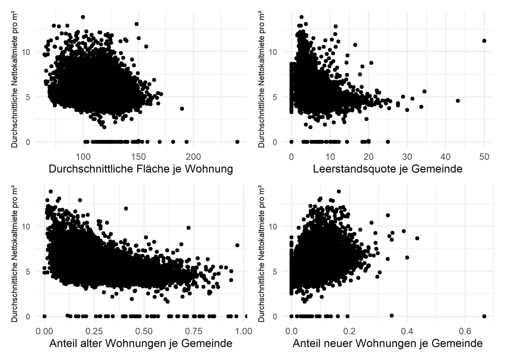

Analyse und Interpretation der Diagramme:

Die Diagramme illustrieren die Beziehung zwischen der durchschnittlichen Nettokaltmiete pro Quadratmeter und unterschiedlichen Merkmalen von Wohnungen sowie Gemeinden. Im ersten Diagramm, das die Wohnfläche pro Wohnung mit den Mietpreisen in Beziehung setzt, zeigt sich ein negativer Zusammenhang: Kleinere Wohnungen erzielen tendenziell höhere Quadratmeterpreise, während bei größeren Wohnungen die Mietpreise sinken. Dabei ist insbesondere bei kleineren Wohnflächen eine erhebliche Streuung der Werte erkennbar. Im zweiten Diagramm wird die Leerstandsquote in Gemeinden untersucht. Hier deutet sich an, dass sehr hohe Leerstandsquoten (über 30 %) mit niedrigeren Mietpreisen einhergehen, obwohl die Streuung der Daten auf einen weniger klaren Zusammenhang hinweist. Das dritte Diagramm veranschaulicht den Einfluss des Anteils alter Wohnungen: Ein höherer Anteil an älteren Bauten in einer Gemeinde korreliert mit sinkenden Quadratmeterpreisen, wobei die Variabilität der Preise mit steigendem Anteil alter Bausubstanz abnimmt. Schließlich zeigt das vierte Diagramm, dass Gemeinden mit einem größeren Anteil neuer Wohnungen tendenziell höhere Mietpreise aufweisen, wobei in diesen Fällen auch die Streuung der Preise geringer ausfällt.

Die Interpretation dieser Zusammenhänge liefert tiefergehende Einsichten in die Struktur und Dynamik des Wohnungsmarktes. Die überdurchschnittlichen Quadratmeterpreise kleinerer Wohnungen lassen sich auf ihre hohe Nachfrage zurückführen, da sie aufgrund niedrigerer absoluter Mietkosten vor allem für Alleinstehende und Paare attraktiv sind. Im Gegensatz dazu werden größere Wohnungen von Familien bevorzugt, die in der Regel mehr Wohnfläche benötigen, jedoch seltener bereit oder finanziell in der Lage sind, hohe Quadratmeterpreise zu zahlen. Die Leerstandsquote weist keinen stark linearen Zusammenhang mit den Mietpreisen auf, was darauf hindeutet, dass sie primär von regionalen und strukturellen Faktoren, wie der wirtschaftlichen Attraktivität einer Gemeinde, beeinflusst wird. Regionen mit hohen Leerstandsquoten könnten strukturschwache Gebiete widerspiegeln, in denen die Wohnungsnachfrage insgesamt gering ist.

Der negative Zusammenhang zwischen dem Anteil alter Wohnungen und den Mietpreisen kann durch die Wahrnehmung älterer Bausubstanz als weniger attraktiv erklärt werden. Solche Gebäude zeichnen sich oft durch geringere Energieeffizienz und einen niedrigeren Modernisierungsstandard aus, was sich auf die Zahlungsbereitschaft der Mieter auswirkt. Der positive Zusammenhang zwischen einem hohen Anteil neuer Wohnungen und höheren Mietpreisen hingegen spiegelt die Attraktivität moderner Wohnstandards wider. Neue Wohnungen zeichnen sich häufig durch eine bessere Energieeffizienz, modernere Ausstattung und höheren Komfort aus, wodurch sie besonders in wirtschaftlich prosperierenden Regionen stärker nachgefragt werden. Gemeinden mit einem hohen Anteil an Neubauten sind daher oft Indikatoren für eine gesteigerte Standortattraktivität, was sich in höheren Mietpreisen niederschlägt.

Weiterhin wäre es von Interesse in die einzelnen Großstädte Deutschlands genauer hineinzuschauen, um dort auf Besonderheiten im Wohnmarkt einzugehen. Im ersten Schritt sollen Sie Eigenschaften in Bezug auf die Wohnungen genauer untersucht werden, um zu verstehen, welche Faktoren den Mietpreis innerhalb der urbanen Räume beeinflussen könnten. Anschließend wäre es von Interesse, auch die demografischen Merkmale der Mieterinnen und Mieter in den Blick zu nehmen. Dabei stellt sich die Frage, ob und in welchem Maße diese Einfluss auf die Mietpreise und deren Struktur nehmen.

In der vorherigen Aufgabe wurden Zusammenhänge zwischen dem Alter von Wohnungen und dem Mietpreis auf Gemeindeebene untersucht. Nun soll der Fokus darauf liegen, wie sich die Wohnungen in größeren Städten hinsichtlich ihres Alters verteilen.

8. Erstellen Sie ein Balkendiagramm für alle nachfolgenden Städte: `Stuttgart, Landeshauptstadt`, `Ulm, Universitätsstadt`, `Düsseldorf, Stadt`, `Berlin, Stadt`. Betrachten Sie dabei, wie das Alter der Wohnungen zwischen den Städten variiert. Sie sollen analysieren, wie groß der Anteil der Wohnungen abhängig nach den jeweiligen Baujahrsgruppen in den Städten ist. Tragen Sie in ihrem Balkendiagramm den *Anteil der Wohnungen nach den Baujahren* (auf der y-Achse) gegeben der *Baujahre für jede Stadt* (auf der x-Achse) ab.

Beschreiben und interpretieren Sie die Grafik. Haben Sie diese Unterschiede erwartet? Begründen Sie warum oder warum nicht.

*Hinweis:* Denken Sie daran das Faktorvariablen in ggplot hilfreich sein können.

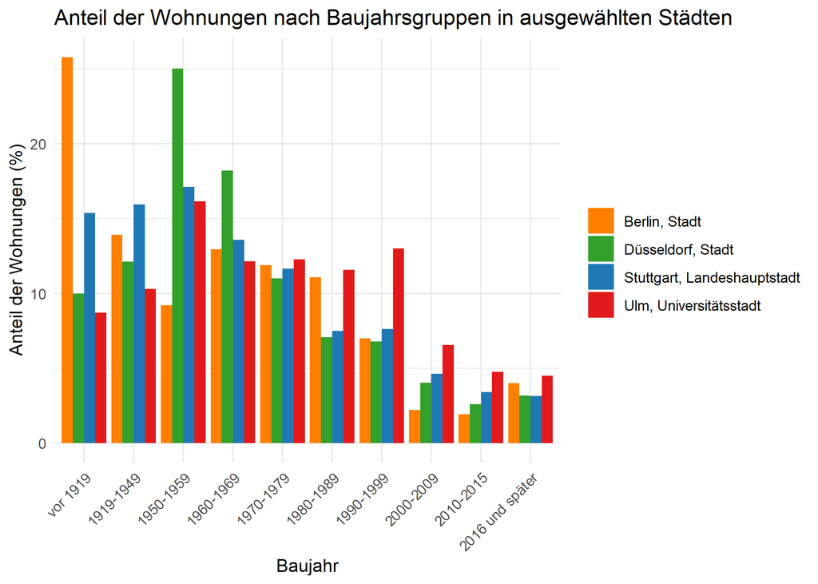

Beschreibung und Interpretation der Grafik

Die vorliegende Grafik zeigt den Anteil der Wohnungen, unterteilt nach Baujahren, in den Städten Berlin, Düsseldorf, Stuttgart und Ulm. Die x-Achse repräsentiert die verschiedenen Baujahrsgruppen, die von „vor 1919“ bis „2016 und später“ reichen, während die y-Achse den prozentualen Anteil der jeweiligen Baujahrsgruppe an den Gesamtwohnungen in den Städten darstellt.

Erwartung und Schlussfolgerung

Die Unterschiede in der Altersstruktur der Wohnungen zwischen den Städten waren größtenteils zu erwarten. Berlin, als historische Großstadt, hat einen besonders hohen Anteil an Wohnungen, die vor 1919 gebaut wurden, was auf ihre lange Geschichte zurückzuführen ist. Dagegen haben Städte wie Düsseldorf, Stuttgart und Ulm, die nach dem Zweiten Weltkrieg ein schnelleres Wachstum und Neubauprojekte erlebten, einen geringeren Anteil an Altbauten und einen höheren Anteil an Wohnungen aus der Mitte des 20. Jahrhunderts sowie jüngeren Baujahren. Diese Unterschiede spiegeln nicht nur die historische Entwicklung der Städte wider, sondern auch die unterschiedlichen Stadterweiterungen und Modernisierungsprozesse im 20. und 21. Jahrhundert. Generell lässt sich ein signifikanter Rückgang der Neubautätigkeit feststellen.

9. Wie in der vorherigen Aufgabe zu sehen war, unterscheidet sich die Situation in Städten in Bezug auf die jeweiligen Baujahre der Wohnungen deutlich. Es wäre noch spannend zu sehen, ob auch das Alter der Bewohner, die Familienstände, oder die Einwanderungshistorie der Bewohner mit unterschiedlichen Mietpreisen assoziiert sind. Hier sollen Sie in einem ersten generellen Schritt ein paar demografische Faktoren einbeziehen, inwiefern diese eine Auswirkung haben. Betrachten Sie folgende Eigenschaften genauer:
- Familienstand
- Alter der Bewohner
- Einwanderungsgeschichte

Erstellen Sie eine oder mehrere passende Diagramme oder Grafiken für die in Aufgabe 8 aufgeführten Städte.

Beschreiben und interpretieren Sie diese. Haben Sie diese Unterschiede erwartet? Begründen Sie warum oder warum nicht. Wo gibt es Ihrer Ansicht nach besondere Auffälligkeiten? Warum kann es bei der unterschiedlichen Einteilung der Altersgruppen zu Problemen kommen? Was wären Möglichkeiten, um etwaige Probleme zu vermeiden?

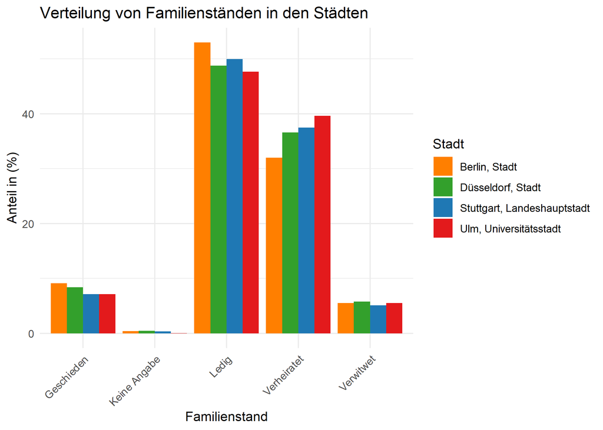

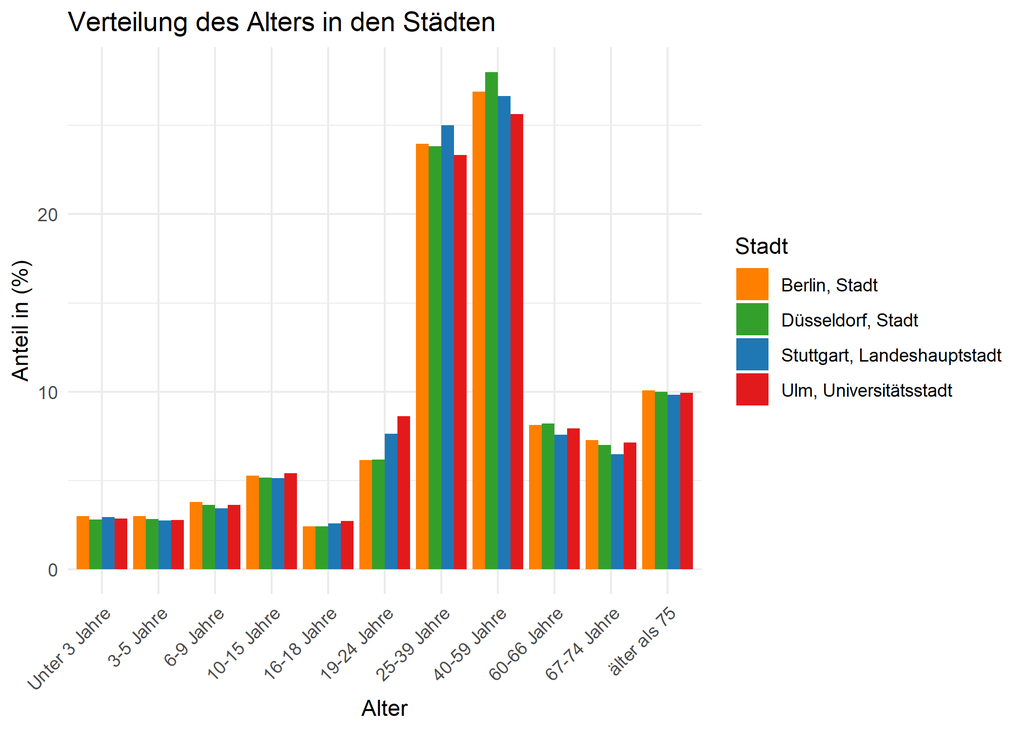

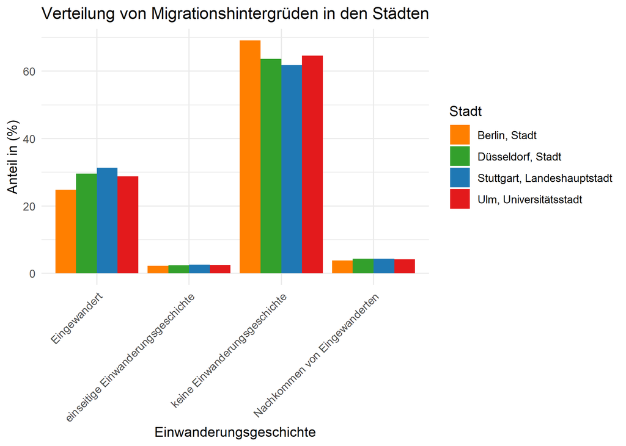

In den bisherigen Analysen wurden demografische und wohnungsbezogene Faktoren in verschiedenen Städten Deutschlands untersucht. Dabei lag der Fokus darauf, wie diese Merkmale in unterschiedlichen Regionen das Mietpreisniveau und dessen Struktur beeinflussen. Aufbauend auf diesen Erkenntnissen soll der Blick nun gezielt auf den Vergleich zwischen Ost- und Westdeutschland gelenkt werden. Diese regionale Differenzierung ermöglicht es, potenzielle Unterschiede und Gemeinsamkeiten zwischen den beiden Landesteilen genauer zu analysieren. Insbesondere wird betrachtet, wie sich die Mietpreisstruktur in Ost- und Westdeutschland darstellt und ob sich hierbei spezifische Muster oder Abweichungen erkennen lassen.

10. Betrachten Sie nun die Städte `Dresden, Stadt`, `Chemnitz, Stadt`, `Stuttgart, Landeshauptstadt`, `Ulm, Universitätsstadt`,`Düsseldorf, Stadt`und `Berlin, Stadt`. Vergleichen Sie in einem ersten Schritt die Anzahl an Einwohnern, den Anteil an Menschen, die deutscher Herkunft sind, den Anteil an neuen und alten Wohnungen, sowie die durchschnittlichen Mietpreise. Erweitern Sie ihre Analyse um die durschnittlichen Wohnflächen.

Erstellen Sie für die genannten Städte eine deskriptive Tabelle. Beschreiben und interpretieren Sie diese. Beantworten Sie insbesondere folgende Fragen:

- In wie weit könnte das Alter der Wohnungen eine Rolle für den Mietpreis spielen?
- Gibt es Auffälligkeiten zwischen den einzelnen Städten in Bezug auf Herkunft der Bewohner, Einwohner und Größe der Wohnungen?
- Warum könnte es problematisch sein, wenn Sie die Städte als ein Ganzes betrachten?
- Sind Ihre Ergebnisse auf die ganze Stadt verallgemeinerbar?
- Was sind ihrer Meinung nach Faktoren, die die unterschiedlichen Mietpreise in Ost und West erklären?
- Welche Maßnahmen wären geeignet, um in Düsseldorf, Ulm und Stuttgart die Mietpreisstruktur anzupassen und bezahlbaren Wohnraum zu schaffen?

| Name Gemeinde | Einwohner | Anteil Einwohner deutscher Herkunft | Anteil neuer Wohnungen | Anteil alter Wohnungen | Quadratmeterpreis | Wohnfläche |
| --- | --- | --- | --- | --- | --- | --- |
| Düsseldorf, Stadt | 611.258 | 77,24% | 5,78% | 22,11% | 9,24 €/m² | 77,56m² |
| Stuttgart, Landeshauptstadt | 610.458 | 74,30% | 6,57% | 31,33% | 10,39 €/m² | 79,76m² |
| Ulm, Universitätsstadt | 127.116 | 78,22% | 9,26% | 19,02% | 8,48 €/m² | 87,64m² |
| Berlin, Stadt | 3.596.999 | 80,46% | 5,92% | 39,72% | 7,67 €/m² | 73,22m² |
| Chemnitz, Stadt | 240.078 | 90,23% | 3,18% | 41,03% | 5,26 €/m² | 71,33m² |
| Dresden, Stadt | 557.782 | 90,69% | 6,62% | 39,61% | 6,92 €/m² | 71,24m² |

Die Tabelle liefert eine detaillierte Übersicht über die demografischen und wohnungsbezogenen Merkmale ausgewählter deutscher Städte. Sie beleuchtet insbesondere die Einwohnerzahlen, den Anteil neuer und alter Wohnungen sowie die durchschnittlichen Quadratmeterpreise, wodurch ein präzises Bild der städtischen Wohnsituation entsteht.

Herausforderungen bei der Gesamtbetrachtung der Städte: Es ist problematisch, die Städte als einheitliches Ganzes zu betrachten, da sie sich in Bevölkerungsstruktur, Wirtschaftskraft und Wohnungsmarkt stark unterscheiden. Ostdeutsche Städte wie Chemnitz und Dresden haben andere Herausforderungen, etwa höhere Leerstandsquoten, während westdeutsche Städte wie Düsseldorf und Stuttgart mit knapperem und teurerem Wohnraum konfrontiert sind. Eine differenzierte Analyse ist daher notwendig.

Verallgemeinerbarkeit der Ergebnisse auf die gesamte Stadt: Die Ergebnisse lassen sich nicht pauschal auf die gesamte Stadt übertragen, da es erhebliche Unterschiede zwischen zentralen und peripheren Stadtteilen gibt. In Städten wie Düsseldorf und Berlin variieren die Mietpreise stark je nach Lage.

Die Mietpreisunterschiede zwischen Ost- und Westdeutschland resultieren aus verschiedenen Faktoren: Die Mietpreisunterschiede zwischen Ost- und Westdeutschland lassen sich durch mehrere Faktoren erklären. Westdeutsche Städte zeichnen sich durch eine stärkere Wirtschaftskraft aus, was zu einer höheren Nachfrage und damit steigenden Mietpreisen führt. In vielen ostdeutschen Städten hingegen übersteigt das Wohnungsangebot die Nachfrage, was niedrigere Preise begünstigt. Zudem haben westdeutsche Städte von größeren Investitionen in den Wohnungsbau profitiert, wodurch dort mehr moderne und hochwertige Wohnungen vorhanden sind.

Maßnahmen zur Mietpreisstruktur Um die Mietpreise in Düsseldorf, Ulm und Stuttgart zu senken und bezahlbaren Wohnraum zu schaffen, bieten sich mehrere Maßnahmen an. Dazu gehört insbesondere die Förderung des sozialen Wohnungsbaus durch gezielte Subventionen, um das Angebot an günstigen Wohnungen zu erweitern. Darüber hinaus könnte eine Optimierung der Genehmigungsverfahren den Neubau beschleunigen und zusätzliche Investitionen anziehen. Anreize für private Investoren, etwa in Form steuerlicher Erleichterungen, würden auch die Schaffung von bezahlbarem Wohnraum vorantreiben.

11. Lesen Sie den [folgenden Artikel](https://www.tagesschau.de/wirtschaft/sozialwohnungen-bau-mangel-101.html). Dort werden Sozialwohnungen thematisiert, warum so viele fehlen und wer davon vor allem betroffen ist. Beantworten Sie anschließend folgende Fragen:
- Welche Bevölkerungsgruppen sind am stärksten von der Sozialwohnungsnot betroffen und inwiefern?
- Was sind Gründe, warum es zu wenige Sozialwohnungen gibt?
- Wie sieht die historische Entwicklung des Sozialwohnungsbaus aus, im Hinblick auf Vorhandensein von Wohnungen und Investitionen in den Bau von neuen Wohnungen?
- Welche Anreize könnten Investoren motivieren, mehr Sozialwohnungen zu bauen?
- Welche innovativen Ansätze können Bauherren verfolgen, um die Kosten für den Wohnungsbau zu senken?

Im Artikel „ Millionen Sozialwohnungen fehlen“ von der Tagesschau wird die angespannte Situation auf dem Sozialwohnungsmarkt analysiert. Insbesondere Menschen mit begrenzten finanziellen Mitteln stehen vor erheblichen Herausforderungen, sich auf dem Wohnungsmarkt zurechtzufinden. Ihre eingeschränkten finanziellen Ressourcen machen sie stark auf Sozialwohnungen angewiesen, deren Verfügbarkeit jedoch kontinuierlich abnimmt. Lukas Siebenkotten, Präsident des Deutschen Mieterbundes, sagte: „Auf dem normalen Wohnungsmarkt haben finanziell schwache Wohnungssuchende kaum eine Chance, eine bezahlbare Wohnung zu finden. Selbst die, die einen Wohnberechtigungsschein haben, bekommen oft keine Sozialwohnung, weil einfach nicht genug da sind. Sie stehen auf Wartelisten.“ Ein Hauptgrund für den Mangel sind die stark gestiegenen Zinsen, Baukosten und Lieferkettenprobleme, verstärkt durch die Ukraine-Krise. Diese treiben die Kosten für Bauvorhaben in die Höhe. Geförderte Projekte, die früher Renditen ermöglichten, sind für Investoren zunehmend unrentabel. Viele Städte arbeiten laufende Baustellen ab, planen jedoch kaum neue Projekte. In den 1990er-Jahren standen in Deutschland noch rund drei Millionen Sozialwohnungen zur Verfügung, doch diese Zahl ist inzwischen auf 1,1 Millionen gesunken. Dennoch wurde ein erster Schritt unternommen: 2023 sollen 1,28 Milliarden Euro in den sozialen Wohnungsbau fließen – ein signifikanter Anstieg gegenüber den 750 Millionen Euro im Jahr 2022. Doch die Umsetzung bleibt herausfordernd, da der soziale Wohnungsbau Ländersache ist und Förderprogramme uneinheitlich gestaltet sind. Außerdem sind gezielte Anreize erforderlich, um den sozialen Wohnungsbau für Investoren attraktiver zu gestalten. Dazu zählt insbesondere eine signifikante Ausweitung staatlicher Fördermittel, um den stark gestiegenen Baukosten entgegenzuwirken. Ebenso entscheidend ist der Abbau bürokratischer Hemmnisse: Weniger Auflagen und beschleunigte Genehmigungsverfahren könnten das Bauen effizienter und kostengünstiger machen. Ergänzend wäre eine rasche Erschließung von Bauland notwendig, um das Angebot an verfügbaren Flächen zu erhöhen. Ein weiterer Ansatz ist das im Koalitionsvertrag vorgesehene Modell der “Wohngemeinnützigkeit”, das durch steuerliche Vorteile gezielt jene Unternehmen fördern soll, die preisgünstigen Wohnraum schaffen. Die Umsetzung dieser Maßnahmen ist dringend geboten, um den wachsenden Bedarf an bezahlbarem Wohnraum zeitnah zu decken. Zudem können Bauherren verschiedene innovative Ansätze verfolgen, um die Kosten im Wohnungsbau zu senken. Eine Möglichkeit ist, die Gebäudestruktur zu optimieren, etwa durch kleinere Treppenhäuser und reduzierte Wandstärken, was den Materialverbrauch und somit die Kosten verringert. Der vermehrte Einsatz von Holz als Baumaterial wird ebenfalls als kostengünstige und effiziente Lösung vorgeschlagen, da es oft schneller und preiswerter verarbeitet werden kann. Zudem empfiehlt Jan Eitel, Gesellschafter der Immprinzip GmbH im Saarland, die Verwendung von Flachdächern ohne Attika, um zusätzliche Baukosten zu vermeiden. Der Schallschutz entspricht in den meisten Fällen bereits den höchsten Standards, sodass keine weiteren Kosten in diesem Bereich erforderlich sind. Diese Ansätze fokussieren sich auf eine intelligente und ressourcenschonende Bauweise, die die Kosten senkt, ohne die Qualität des Wohnraums zu beeinträchtigen. Der Artikel zeigt eindrücklich, wie dringend politisches und gesellschaftliches Handeln nötig ist, um diesen Missstand zu beheben.

12. Gerade die Politik ist gefordert, bezahlbaren Wohnraum zu realisieren. Dabei gibt es eine Viezahl an politischen Maßnahmen, die aufgestellt wurden und umfangreich diskutiert werden. Betrachten Sie die folgenden Maßnahmen, welche helfen sollen, die angespannte Lage auf dem Mietmarkt zu entlasten. Argumentieren Sie, warum diese Maßnahmen sinnvoll/nicht sinnvoll sind und in welcher Art und Weise diese umgesetzt werden können.
1. “Fachleute fordern, die Regulierung von Bestandsmieten zu lockern, damit sich ihr Niveau den Neuvertragsmieten annähert, mehr Menschen umziehen und sich Wohnraum besser verteilt.”
2. “Eine weitere Möglichkeit wäre, Mieterhöhungen bei Neuvertragsmieten zu begrenzen.”
3. “Am einfachsten ist es, wenn vor allem in Großstädten, wo bezahlbarer Wohnraum fehlt, mehr gebaut wird.”
4. “Am besten wäre es, wenn zukünftig mehr Vermieter in regelmäßigen Abständen die Miete anpassen.”

Lockerung der Regulierung von Bestandsmieten: Eine Lockerung der Bestandsmietenregulierung könnte die Verteilung von Wohnraum effizienter gestalten, indem Mieter in weniger bevorzugte, aber dennoch erschwingliche Gebiete umziehen. Allerdings birgt diese Maßnahme das Risiko, sozial schwächere Mieter zu verdrängen und Gentrifizierung zu fördern, da Mieten in vielen Regionen ansteigen würden. Eine schrittweise Einführung und ein erweiterter sozialer Schutz wären entscheidend, um sicherzustellen, dass diese Maßnahme sozial verträglich und gerecht umgesetzt wird.

Begrenzung von Mieterhöhungen bei Neuvertragsmieten: Die Begrenzung von Mieterhöhungen bei Neuvertragsmieten könnte dazu beitragen, die Mietpreise in angespannten Märkten zu stabilisieren. Jedoch könnte diese Maßnahme potenzielle Investoren abschrecken und so den Neubau von Wohnungen langfristig bremsen. Eine Kombination mit zusätzlichen Fördermaßnahmen würde die Wirksamkeit dieser Maßnahme jedoch erheblich steigern.

Förderung des Neubaus in Großstädten: Der Neubau von Wohnungen in Großstädten ist eine unerlässliche Maßnahme zur Bekämpfung des Wohnraummangels. Zwar sind die damit verbundenen Kosten und bürokratischen Hürden beträchtlich, ohne gezielte Förderungen könnte der Prozess jedoch unzureichend und teuer bleiben. Die Beschleunigung der Genehmigungsverfahren und gezielte Anreize für Investoren sind entscheidend, um den Neubau effektiv voranzutreiben.

Regelmäßige Mietanpassungen durch Vermieter: Regelmäßige Mietanpassungen könnten dazu beitragen, die Mietpreise auf einem stabilen Niveau zu halten und den Vermietern zu ermöglichen, gestiegene Kosten auszugleichen. In wirtschaftlich unsicheren Zeiten könnten diese Anpassungen jedoch für Mieter zu einer erheblichen Belastung führen. Eine transparente Berechnungsmethodik und Schutzmaßnahmen für benachteiligte Mietergruppen sind unerlässlich, um die negativen Auswirkungen auf sozial schwächere Mieter zu vermeiden.

Fazit: Unter den vorgeschlagenen Maßnahmen stellt der Neubau von Wohnungen in Großstädten die langfristig nachhaltigste Lösung zur Bekämpfung des Wohnraummangels dar. Trotz der baulichen Herausforderungen und hohen Kosten würde zusätzlicher Wohnraum den Markt merklich entlasten und zu einer langfristigen Stabilisierung der Mietpreise führen. Um diesen Prozess zu beschleunigen, sind gezielte Förderungen sowie eine Optimierung der Genehmigungsverfahren von entscheidender Bedeutung.

# Einzelne Stadtteile in Deutschland

In allen vorherigen Aufgaben haben Sie die Städte, Gemeinden oder auch Landkreise immer als ein Ganzes betrachtet. Jedoch ist es schwierig gerade in Großstädten wie Berlin, Düsseldorf oder auch Stuttgart allgemeine Aussagen über die Mietsituation auf Stadtebene zu treffen. Dies liegt unter anderem daran, dass unterschiedliche Stadtviertel unterschiedliche demografische Eigenschaften, sowie eine unterschiedliche Mietstruktur aufweisen können. Hier wäre es sinnvoll sich mit dem Stadtbild und der Verteilung der Mieten genauer auseinanderzusetzen, um zu sehen, wie sich Mieten innerhalb der Stadt verteilen. Wie in Aufgabe 10 zu sehen war, weisen die Städte im Westen Deutschlands untereinander, sowie die Städte im Osten ähnliche Merkmale auf, weshalb Sie sich in den folgenden Aufgaben auf je eine große und eine kleinere Stadt aus beiden Regionen konzentrieren.

13. In dieser Aufgabe sollen Sie ihren Datensatz aus Aufgabe 4, bei dem Sie Kartendaten und Informationen zu Mieten und LEQ auf 1km-Gitterebene heruntergeladen und zusammengefügt haben, verwenden und vier Karten zeichnen, welche die Verteilung der Nettokaltmieten in den Stadtteilen der Städte “Stuttgart, Landeshauptstadt”, “Ulm, Universitätsstadt”, “Chemnitz, Stadt” und “Dresden, Stadt” anschaulich visualisieren.

Erstellen Sie vier Grafiken, beschreiben und interpretieren diese. Gehen Sie insbesondere auf folgende Fragen ein:

- Welche Besonderheiten fallen Ihnen bei diesen Städten auf?
- Gibt es eine Segregation in Bezug auf die Mieten in einzelnen Stadtteilen?
- Falls es eine Segregation gibt, welche Konsequenzen könnte dies haben?
- Welche Rolle spielen geografische oder infrastrukturelle Faktoren bei den Mietpreisen?
- Gibt es Unterschiede zwischen Städten im Osten und Westen Deutschlands, falls ja, welche Einflüsse in Bezug auf Wirtschaft und Arbeitsmarkt könnte dies in den jeweiligen Städten haben?

*Hinweis:* Wenn Sie einheitliche Legenden für die Karten haben möchten und die vier Städte nebeneinander oder untereinander darstellen wollen, so empfiehlt sich das Paket `ggpubr` und dort der Befehl `ggarrange`.

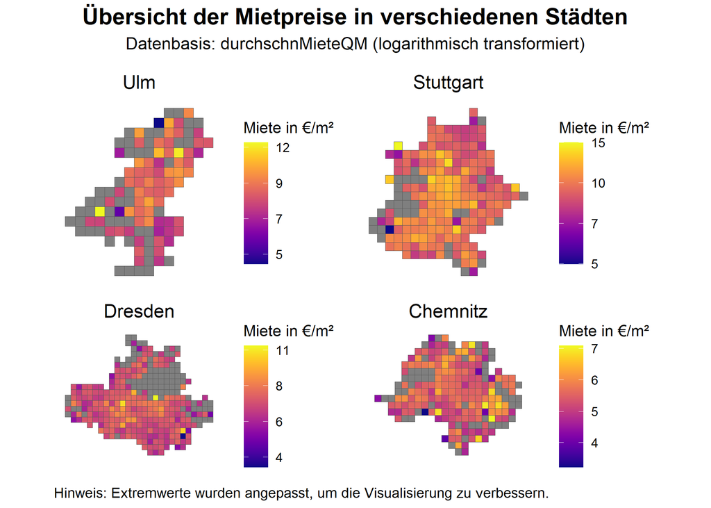

In Stuttgart gibt es einen auffälligen Ausreißer im Nordwesten mit besonders hohen Mietpreisen. Hier liegen die Mietpreise pro QM im Durchschnitt bei knapp 40 EUR. Damit dieser Ausreiser in der Visualisierung der Karte nicht dominiert wurde er angepasst. Wahrscheinlich gibt es in diesem Stadtteil exklusive Wohngegenden oder spezielle Bauprojekte.

In Chemnitz weist ein kleiner Bereich der Stadtmitte vergleichsweise niedrige Mietpreise auf, was auf geförderten Wohnraum, insbesondere für Studierende, hindeuten könnte, da sich die Universität in der Nähe befindet. In Ulm ist der Süden der Stadt tendenziell günstiger.

In den Städten sind durchaus Segregationen in den Mietpreismodellen erkennbar, was auf eine unterschiedliche Verteilung von Wohnraumqualität und -angebot hinweist. Solche Segregationen könnten langfristig zu einer Vertiefung der sozialen Ungleichheit führen, da einkommensschwächere Bevölkerungsgruppen tendenziell in günstigeren, weniger gut ausgestatteten Stadtteilen wohnen. In Stuttgart beispielsweise sind im Norden und Osten der Stadt weite Flächen mit niedrigeren Mietpreisen zu finden, was auf eine wirtschaftliche Ungleichverteilung innerhalb der Stadt hindeutet. Die infrastrukturellen Faktoren, wie Nähe zu öffentlichen Verkehrsmitteln oder das Vorhandensein von Arbeitsplätzen und Bildungseinrichtungen, beeinflussen maßgeblich die Mietpreise.

Geografische Faktoren, wie die Lage in städtischen Zentren oder Randgebieten, spielen ebenfalls eine entscheidende Rolle. In den Stadtzentren, wie in Ulm, sind die Mieten höher, was mit der zentralen Lage und der besseren Erreichbarkeit von Arbeitsplätzen und Dienstleistungen zusammenhängt. In den Randgebiete sind die Mieten hingegen niedriger, was auf weniger Nachfragen und geringere Entwicklungsdichte zurückzuführen ist. Ein starker Unterschied zwischen Ost- und Westdeutschland lässt sich in den Mietpreismodellen erkennen, da Städte wie Stuttgart, als westdeutsche Stadt, deutlich höhere Mietpreise aufweisen als Städte im Osten wie Chemnitz oder Dresden. Dieser Unterschied kann durch verschiedene wirtschaftliche Faktoren wie die Nachwirkungen der Wende und die Entwicklung von Arbeitsmärkten und Investitionen in der jeweiligen Region beeinflusst werden. In westdeutschen Städten gibt es eine höhere wirtschaftliche Dynamik, was sich auch in den höheren Mieten widerspiegelt.

14. Nachdem Sie in Aufgabe 13 die Verteilung der Mieten der einzelnen Stadtteile visualisiert haben, sollten Sie in dieser Aufgabe den Anteil der Leerstandsquoten in den Stadtteilen der Städte “Stuttgart, Landeshauptstadt”, “Ulm, Universitätsstadt”, “Chemnitz, Stadt” und “Dresden, Stadt” veranschaulichen.

Erstellen Sie vier Grafiken, beschreiben und interpretieren diese. Gehen Sie insbesondere auf folgende Fragen ein:

- Was könnten Gründe sein, dass die Leerstandsquote in bestimmten Stadtteilen höher ist, als in anderen?
- Welche Besonderheiten fallen Ihnen bei diesen Städten auf? Auch im Hinblick auf ihre Erkenntnisse aus Aufgabe 13.
- Vergleichen Sie die Grafiken aus Aufgabe 13 und Aufgabe 14. Was könnte der Grund für die unterschiedlichen Muster sein?
- Welche Maßnahmen ergreifen Städte mit hohen Leerstandsquoten, um diese zu reduzieren?

*Hinweis:* Wenn Sie einheitliche Legenden für die Karten haben möchten und die vier Städte nebeneinander oder untereinander darstellen möchten, so empfiehlt sich das Paket `ggpubr` und dort der Befehl `ggarrange`.

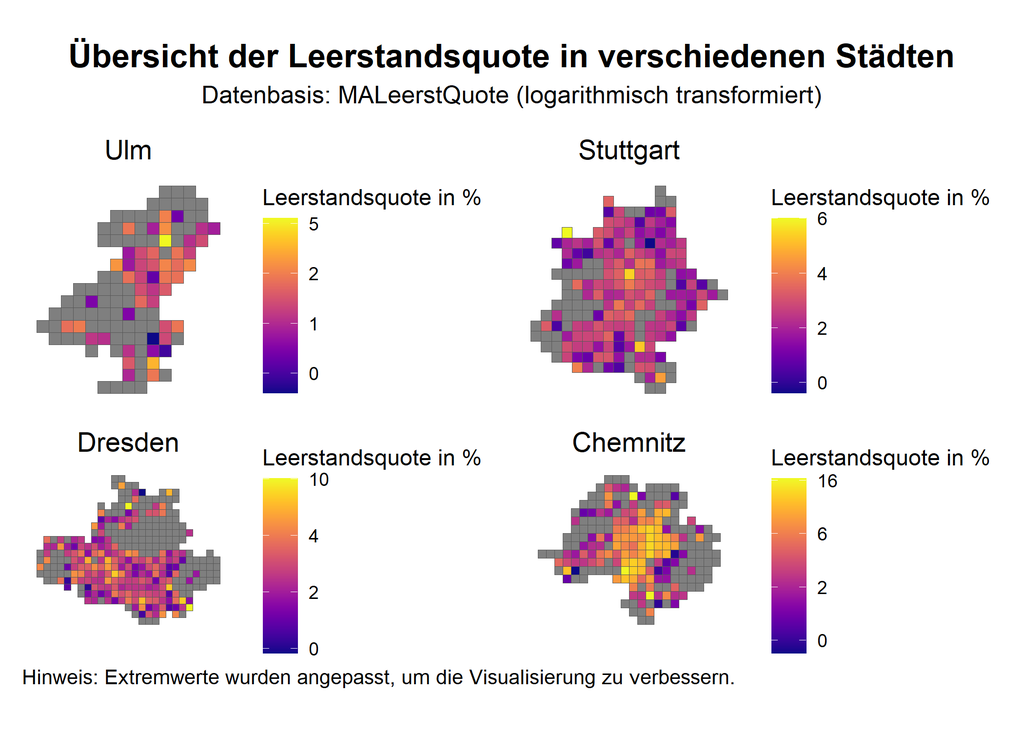

Die Grafik stellt die Verteilung der Leerstandsquoten in den Städten Stuttgart, Ulm, Chemnitz und Dresden dar. Die Werte sind logarithmisch transformiert, um hohe Unterschiede besser zu visualisieren. Dabei fallen zwischen den Städten deutliche Unterschiede auf. Insgesamt zeigt sich, dass die Leerstandsquoten in ostdeutschen Städten wie Chemnitz und Dresden deutlich höher sind als in westdeutschen Städten wie Stuttgart und Ulm. Dies verdeutlicht die nach wie vor bestehenden strukturellen Unterschiede zwischen Ost und West.

In Chemnitz sind die Leerstandsquoten besonders im Stadtzentrum auffällig hoch, während die Randgebiete deutlich geringere Quoten aufweisen. Dies lässt sich durch wirtschaftliche Strukturschwächen und die Abwanderung aus der Stadt erklären, was insbesondere das Zentrum unattraktiv macht. Stuttgart zeigt ein ähnliches, jedoch weniger stark ausgeprägtes Muster: Die Leerstandsquoten sind im Zentrum etwas höher, während die Randgebiete niedrigere Werte aufweisen, was vermutlich mit erschwinglicherem Wohnraum und einer besseren Lebensqualität am Stadtrand zusammenhängt.

Dresden weist eine uneinheitliche Verteilung der Leerstandsquoten auf, ohne dass eine klare Dominanz von Zentrum oder Stadtrand erkennbar ist. Diese heterogene Verteilung könnte auf unterschiedliche Entwicklungsstände der Stadtteile und variierende Attraktivitätsfaktoren hinweisen. In Ulm sind die Leerstandsquoten insgesamt sehr niedrig, was auf eine stabile Nachfrage nach Wohnraum und die Attraktivität der Stadt als Wohn- und Arbeitsort hinweist. Allerdings ist die Datenlage hier überwiegend auf das Stadtzentrum begrenzt, sodass Randgebiete nicht ausreichend berücksichtigt werden können.

Ein markanter Unterschied zeigt sich zwischen den ostdeutschen und westdeutschen Städten: Während Chemnitz und Dresden nach wie vor mit hohen Leerstandsquoten kämpfen, weisen Stuttgart und Ulm insgesamt geringere Werte auf. Dies spiegelt die wirtschaftlichen Unterschiede zwischen den Regionen wider, die noch immer von den Nachwirkungen der Wiedervereinigung geprägt sind.

Insgesamt zeigt die Grafik, dass die Leerstandsquoten sowohl von regionalen als auch stadtinternen Faktoren wie Infrastruktur, Attraktivität und wirtschaftlichen Rahmenbedingungen beeinflusst werden. Insbesondere die ostdeutschen Städte benötigen gezielte Maßnahmen wie Sanierungsförderungen und die Belebung von Stadtzentren, um Leerstände zu reduzieren. Westdeutsche Städte wie Stuttgart und Ulm stehen vor weniger akuten Herausforderungen, sollten jedoch auf eine nachhaltige Stadtentwicklung achten, um mögliche Probleme langfristig zu vermeiden.

15. Die aktuellen Mietpreise und deren Entwicklungen hindern in Deutschland immer mehr Menschen daran, dass sie sich eine neue geeignete Wohnung suchen. Personen, die aufgrund ihrer aktuellen Lebenssituation sich nach einer neuen Wohnung umsehen, finden oft keine oder können sich diese nicht leisten. Doch worin liegen die Ursachen und Probleme?

Beantworten Sie hierzu folgende Fragen:

- Was versteht man unter dem Lock-in-Effekt, speziell in Bezug auf den Mietmarkt? Wer ist davon vor allem betroffen und warum?
- Gibt es aktuell Möglichkeiten, die vor allem diese “betroffenen” Personen haben, um an bezahlbaren Wohnraum zu gelangen?
- Worin liegen die Ursachen, dass Bestandsmieten (Mieten aus bestehenden Verträgen) und Angebotsmieten (Mieten aus Neuverträgen) so stark voneinander abweichen?

Gehen Sie in ihrer Argumentation auch auf die Grafiken und Ergebnisse der Aufgaben 11, 13 und 14 ein.

Definition des Lock-in Effekts: Der Lock-in-Effekt beschreibt die Situation, in der Verbraucher dazu verleitet werden, bei einem Anbieter zu bleiben, da ein Wechsel mit Nachteilen verbunden ist. Diese Anreize können sowohl finanzieller als auch psychologischer Natur sein und entstehen oft durch hohe Umstellungskosten oder exklusive Inhalte und Dienstleistungen. [^1] Im Mietmarkt bezieht sich der Lock-in-Effekt auf Mieter*innen, die in ihrer aktuellen Wohnung bleiben, weil sie die hohen Mietpreise für neue Wohnungen, die Umzugskosten oder die Unsicherheit über zukünftige Mietpreisentwicklungen vermeiden wollen. Auch wenn die Wohnung nicht mehr ihren Bedürfnissen entspricht, scheuen sie einen Umzug, um nicht mit höheren Kosten konfrontiert zu werden. Besonders betroffen sind: Langjährige Mieter(innen), die von günstigen Bestandsmieten profitieren und deshalb einen Umzug scheuen, um nicht mit erheblichen Mietsteigerungen konfrontiert zu werden. Senior(innen) und Menschen mit geringem Einkommen, die sich teureren Wohnraum oft nicht leisten können oder aufgrund gesundheitlicher Einschränkungen nicht in der Lage sind umzuziehen. Ebenso Familien und Menschen mit speziellen Bedürfnissen, die auf bestimmte Wohnungstypen angewiesen sind und angesichts der angespannten Marktlage keine bezahlbare Alternative finden.

Trotz der angespannten Lage auf dem Mietmarkt in vielen Städten gibt es für betroffene Mieter(innen) verschiedene Möglichkeiten, bezahlbaren Wohnraum zu finden, die stark von geografischen Faktoren und der Lage abhängen. Besonders relevant sind hierbei die Unterschiede zwischen städtischen Zentren und Randgebieten sowie zwischen Ost- und Westdeutschland (vgl. Aufgabe 13). In Stadtzentren wie Ulm sind die Mieten aufgrund der zentralen Lage, der Nähe zu Arbeitsplätzen und wichtigen Dienstleistungen in der Regel höher. Für Menschen mit geringem Einkommen oder speziellen Bedürfnissen, die sich diese Mieten nicht leisten können, gestaltet sich die Suche nach einer passenden Wohnung oft schwierig. Eine attraktive Alternative könnten Randgebiete oder ländliche Regionen sein, in denen die Mieten aufgrund einer geringeren Nachfrage und einer niedrigeren Entwicklungsdichte tendenziell günstiger ausfallen. Personen, die bereit sind, längere Pendelstrecken auf sich zu nehmen, finden dort häufig bezahlbaren Wohnraum. Ein weiterer wichtiger Faktor sind die Leerstandsquoten (vgl. Aufgabe 14), die sowohl von stadtinternen als auch regionalen Gegebenheiten beeinflusst werden. Städte im Osten Deutschlands, wie Chemnitz oder Dresden, bieten im Vergleich zu westdeutschen Städten oft günstigeren Wohnraum, da die Leerstände dort höher sind und die Nachfrage geringer ist. Für Menschen, die auf der Suche nach bezahlbarem Wohnraum sind, stellt ein Umzug in solche Regionen eine durchaus lohnenswerte Alternative dar.

Es gibt mehrere Gründe, warum Bestandsmieten und Angebotsmieten deutlich voneinander abweichen. Ein wesentlicher Faktor ist die Mietpreisbremse, die in vielen deutschen Städten die Mietsteigerungen für Bestandsmieten begrenzt. Diese Regelung schützt Mieter*innen vor übermäßigen Erhöhungen, gilt jedoch nur für bestehende Mietverhältnisse. Bei Neuvermietungen hingegen sind die Mieten nicht durch diese Bremse gedeckt, was zu deutlich höheren Preisen führt, da der Markt hier unreguliert ist. Schließlich sorgt auch die wirtschaftliche Unsicherheit und der Inflationsdruck für eine Erhöhung der Angebotsmieten, da die Betriebskosten, etwa für Energie, steigen. Bei Bestandsmieten bleiben die Mietpreise hingegen oft stabil, da sie an den ursprünglichen Vertragsbedingungen ausgerichtet sind. Ein weiterer Grund ist die gestiegene Nachfrage nach Wohnraum in vielen Großstädten, die die Angebotsmieten deutlich anhebt. Neubauten und modernisierte Bestandswohnungen orientieren sich an den aktuellen Marktbedingungen und verlangen höhere Preise.

[^1] Quelle: (https://www.pureconsultant.de/de/management/lock-in-effekt/)

# Stadt vs. Land

Bisher haben Sie sich intensiv mit der Wohnsituation in Deutschland auseinandergesetzt und dabei insbesondere die Unterschiede zwischen Ost- und Westdeutschland betrachtet. Im Fokus standen dabei die Mietpreisentwicklung und die Rolle verschiedener Faktoren wie demografische Merkmale, Leerstandsquote, Eigentümerquote, sowie die Wohnfläche. Diese Analysen haben wertvolle Erkenntnisse über die regionale Dynamik des Mietmarkts geliefert.

Nun sollen Sie ihren Blickwinkel erweitern und den Fokus auf eine weitere Ebene der Analyse richten. Im Kern sollen Sie den Unterschied zwischen städtischen Regionen, insbesondere Großstädten, und ländlichen Gebieten untersuchen. Hierbei soll die Mietstruktur in diesen beiden Raumtypen analysiert werden, ob sich die Strukturen von Stadt und Land voneinander unterscheiden.

16. Betrachten Sie in einem ersten Schritt die Wohnungen abhängig ihres Alters. Erstellen Sie dazu eine passende Grafik, die die Verteilung der Wohnungen nach Altersgruppen für die Stadt `Stuttgart, Landeshauptstadt` (Landkreis: Stuttgart, Stadtkreis) im Vergleich zum `Alb-Donau-Kreis` und `Ostalbkreis` darlegt.

Beschreiben und interpretieren Sie ihre Grafik. Woran könnte es liegen, dass es in Stuttgart (in der Stadt) deutlich mehr Altbauwohnungen als auf dem Land gibt? Könnten politische Maßnahmen ihrer Ansicht nach helfen, dass auch in Großstädten mehr neue Wohnungen erbaut und zur Vermietung zur Verfügung gestellt werden?

*Hinweis 1:* Nutzen Sie für die Visualisierung einen Mosaik- oder ein “stacked” Balkendiagramm. Eine Idee, wie Sie das Ganze darstellen können, finden Sie [hier](https://r-graph-gallery.com/).

*Hinweis 2:* Für Stuttgart soll der komplette Landkreis (“Stadtkreis”) untersucht werden.

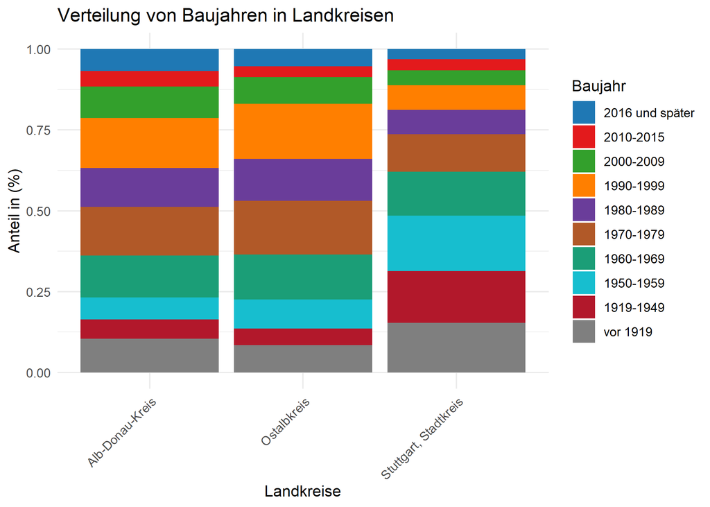

Die Grafik zeigt die prozentuale Verteilung von Baujahren in den Landkreisen Stuttgart, Alb-Donau-Kreis und Ostalbkreis. Dabei fallen deutliche Unterschiede zwischen der Stadt Stuttgart und den ländlicheren Regionen auf. Besonders auffällig ist, dass in Stuttgart ein deutlich höherer Anteil an Altbauwohnungen aus der Kategorie „vor 1919“ vorhanden ist. Im Gegensatz dazu dominieren in den ländlichen Gebieten wie dem Alb-Donau-Kreis und dem Ostalbkreis Wohngebäude aus späteren Baujahren.

Die Ursache für den hohen Anteil an Altbauwohnungen in Stuttgart liegt vermutlich in der historischen Entwicklung der Stadt als früh industrialisiertes Zentrum. Hier wurden viele Gebäude vor dem Ersten Weltkrieg errichtet, und der Platzmangel in der Innenstadt hat dazu geführt, dass diese Altbauten häufig saniert statt abgerissen wurden. In den ländlicheren Regionen steht hingegen mehr Fläche für Neubauten zur Verfügung, was den höheren Anteil neuerer Gebäude erklärt.

Um den Wohnungsbau in Städten wie Stuttgart anzukurbeln, könnten politische Maßnahmen ergriffen werden. Förderprogramme für den sozialen Wohnungsbau oder steuerliche Anreize für die Nachverdichtung in städtischen Gebieten könnten den Neubau fördern. Gleichzeitig könnten vereinfachte Bauvorschriften und gezielte Investitionen in die Infrastruktur die Attraktivität neuer Projekte erhöhen. Eine nachhaltige Stadtentwicklung, die Altbauten erhält und gleichzeitig Neubauten ermöglicht, ist hier von zentraler Bedeutung.

In einem weiteren Schritt sollen Sie nun die Mietpreise und deren Verteilung analysieren. Hierbei sollen Sie neben der Leerstands- und Eigentümerquote auch auf die Verteilung der Wohnungen nach deren Wohnfläche achten und diese untersuchen.

17 (a). Erstellen Sie zuerst eine Tabelle, die die durchschnittlichen Mietpreise mit der Leerstands- und Eigentümerquote darstellt. Was fällt ihnen dabei besonders auf? Beschreiben und interpretieren Sie ihre Tabelle.

17 (b). Erstellen Sie eine weitere Grafik, die die Verteilung der Wohnungen nach den einzelnen Wohnungsgrößen(<40m² bis >=200m²) abbildet. Stellen Sie darüber hinaus den durchschnittlichen Mietpreis je Landkreis in einer weiteren Grafik dar. Beschreiben und interpretieren Sie ihre Grafiken. Gehen Sie insbesondere auf die Frage ein, ob es Sinn macht sich vor allem den Ostalbkreis oder Alb-Donau-Kreis als ein Ganzes anzusehen und inwieweit überhaupt ein Vergleich zwischen Stadt und ländlicher Region möglich ist.

*Hinweis:* Hier sollen Sie erneut auf dieselben Städte und Landkreise aus Aufgabe 16 eingehen!

Vergleich der durschn. Miete, Leerstandsq. und Eigentümerq. nach Landkreis

[output not shown]

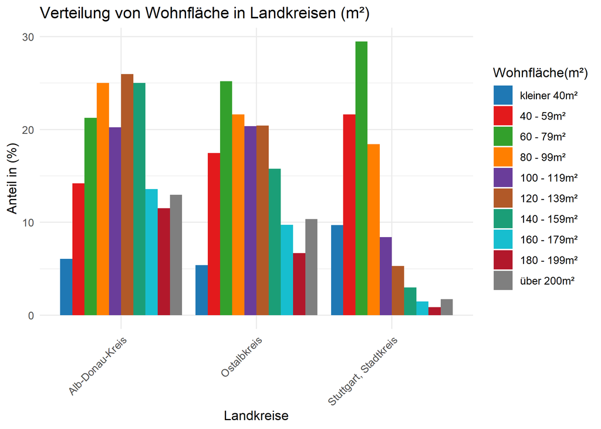

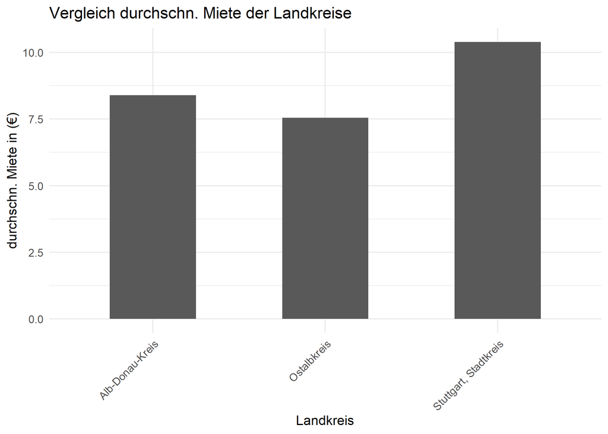

17a Die Tabelle vergleicht die durchschnittliche Miete, die Leerstandsquote und die Eigentümerquote in den Landkreisen Alb-Donau-Kreis, Ostalbkreis und Stuttgart (Stadtkreis). Dabei sind deutliche Unterschiede zwischen den ländlichen Landkreisen und Stuttgart als städtischer Region erkennbar.

Bezüglich der Leerstandsquote fällt auf, dass Stuttgart mit 3,46% den niedrigsten Wert aufweist, was auf eine hohe Nachfrage und eine relativ geringe Verfügbarkeit von freien Wohnungen hinweist. Im Vergleich dazu sind die Leerstandsquoten in den ländlicheren Landkreisen Alb-Donau-Kreis (5,34%) und Ostalbkreis (5,09%) etwas höher, was möglicherweise mit einer geringeren urbanen Entwicklung und einer weniger dynamischen Nachfrage nach Wohnraum in diesen Regionen zusammenhängt.

Die Eigentümerquote zeigt den größten Unterschied: In Stuttgart liegt der Anteil der Eigentümer mit 31,15% deutlich niedriger als in den Landkreisen Alb-Donau-Kreis (71,44%) und Ostalbkreis (70,59%). Dies ist typisch für städtische Gebiete, in denen der Mietmarkt stärker ausgeprägt ist, während in ländlichen Regionen mehr Menschen Eigentum besitzen, oft aufgrund des geringeren Wohnraumbedarfs und der niedrigeren Preise.

Insgesamt lässt sich feststellen, dass Stuttgart im Vergleich zu den ländlicheren Landkreisen höhere Mieten, niedrigere Leerstandsquoten und eine geringere Eigentümerquote aufweist, was auf die urbanen Strukturen und Marktverhältnisse der Großstadt hinweist.

17b Die beiden Grafiken zeigen markante Unterschiede zwischen städtischen und ländlichen Regionen in Bezug auf die Wohnflächenverteilung und die durchschnittlichen Mietpreise in den Landkreisen Alb-Donau-Kreis, Ostalbkreis und Stuttgart, Stadtkreis.

Die Interpretation der Grafiken verdeutlicht, dass Mietpreise und Wohnflächen stark von der urbanen oder ländlichen Prägung der Region abhängen. Städte wie Stuttgart stehen exemplarisch für die Herausforderungen einer begrenzten Fläche und einer hohen Nachfrage, während ländliche Regionen größere Wohnungen zu niedrigeren Preisen bieten. Dies unterstreicht die Bedeutung, die strukturellen Unterschiede bei Vergleichen zwischen Stadt und Land zu berücksichtigen.

Die Frage, ob es sinnvoll ist, den Alb-Donau-Kreis und den Ostalbkreis als eine Einheit zu betrachten, lässt sich bejahen, da die Wohnflächenverteilung und Mietpreise in beiden Landkreisen sehr ähnlich sind. Dies deutet darauf hin, dass ländliche Regionen oftmals vergleichbare Merkmale aufweisen. Ein direkter Vergleich zwischen Stadt und Land ist jedoch nur bedingt möglich, da die Unterschiede in Infrastruktur, Bevölkerungsdichte und wirtschaftlichen Rahmenbedingungen signifikant sind. Dennoch können solche Vergleiche hilfreich sein, um Trends und Entwicklungsmöglichkeiten in den jeweiligen Regionen zu identifizieren.

Insgesamt ergänzen sich die Grafiken und verdeutlichen, dass die städtische oder ländliche Prägung einer Region einen erheblichen Einfluss auf die Wohnbedürfnisse und -angebote hat. Sie zeigen exemplarisch die Herausforderungen und Chancen, die sich aus den unterschiedlichen Lebensrealitäten ergeben.

# Zusatzfrage (optional)

Diese Frage ist von der Bearbeitung her etwas schwieriger. Bevor Sie sich an diese Aufgabe machen, sollten Sie sicherstellen, dass Sie alle vorherigen Fragen ausführlich beantwortet haben. Eine korrekte Beantwortung dieser Frage gibt einen Punktebonus von 3 Punkten (das Projekt umfasst insgesamt 30 Punkte, inkl. Screencast).

Nachdem Sie sich in den bisherigen Aufgaben ausführlich mit den allgemeinen Einflussfaktoren auf die Mietpreise befasst haben, rückt nun ein spezifischer Aspekt in den Fokus: die Rolle der Heizungen. Insbesondere werden Sie untersuchen, wie unterschiedliche Heizungsarten und -systeme die Mietpreise beeinflussen können. Diese Betrachtung ermöglicht es ihnen, die bisherigen Analysen zu verfeinern und den Zusammenhang zwischen energetischen Standards und der Entwicklung von Mietkosten genauer zu erfassen. Aufgabe 18 führt Sie somit zu einem weiteren zentralen Detail der Mietpreisentwicklung, das insbesondere vor dem Hintergrund steigender Energiepreise und der Relevanz nachhaltiger Wohnformen an Bedeutung gewinnt.

18. Lesen Sie den Datensatz `Heiztypen_Zensus.csv` ein und speichern diesen als `heiztypen` ab. Neben den Ihnen bekannten Variablen, finden Sie dort 6 weitere Variablen, die Auskunft über die Heizarten der jeweiligen Wohnung geben. Diese werden wie folgt beschrieben:
- HEIZTYP__1: Gebäude mit Heizungsart Fernheizung (Fernwärme) (Anzahl)
- HEIZTYP__2: Gebäude mit Heizungsart Etagenheizung (Anzahl)
- HEIZTYP__3: Gebäude mit Heizungsart Blockheizung (Anzahl)
- HEIZTYP__4: Gebäude mit Heizungsart Zentralheizung (Anzahl)
- HEIZTYP__5: Gebäude mit Heizungsart Einzel- oder Mehrraumöfen (auch Nachtspeicherheizung) (Anzahl)
- HEIZTYP__6: Gebäude mit Heizungsart Keine Heizung im Gebäude oder in den Wohnungen (Anzahl)

Erstellen Sie eine neue Spalte `heiztypen_gesamt`, welche die Summe über alle Heiztypen hinweg bildet. Bestimmen Sie weiterhin den Anteil der jeweiligen Heiztypen je Gemeinde (als Anteil aller Heizarten). Nun sollen Sie eine oder mehrere passende Grafik(en) erzeugen, die je nach durchschnittlicher Größe der Wohnungen die Anteile der verschiedenen Heizungsarten abbilden. Erstellen Sie weiterhin eine oder mehrere passende Grafik(en) die den Zusammenhang zwischen den Heizungsarten und den durschnittlichen Mietpreisen darstellt. Wiederum soll der Anteil der verschiedenen Heizungsarten abhängig der Mietpreise abgebildet werden.

Beschreiben und interpretieren Sie ihre Schaubilder und gehen Sie insbesondere auf folgende Frage ein:

- Gibt es einen Zusammenhang zwischen der Heizungsart und der Größe der Wohnungen?
- Gibt es einen Zusammenhang zwischen der Heizungsart und den Mietpreisen?
- Was könnten Gründe sein, warum in bestimmten Wohnungsgrößen eher bestimmte Heizungstypen eingebaut werden und andere nicht?
- Warum könnte es sein, dass bei manchen Heizungsarten die Mietpreise höher sind als bei anderen?
- Was könnte die Bundesregierung machen, um trotz neuer und moderner Heizungssysteme die Mietpreise nach oben hin zu beschränken?

*Hinweis 1:* Überlegen Sie sich, ob es ihrer Ansicht nach Sinn macht, die jeweiligen Wohnungsgrößen und durchschnittlichen Mietpreise in Segmente zu unterteilen.

*Hinweis 2:* Eine Möglichkeit die Beziehung zwischen Heizungsarten und Wohnungsgrößen bzw. Heizungsarten und Mietpreisen zu visualisieren wäre beispielsweise ein “stacked” oder “grouped” Balkendiagramm. Überlegen Sie sich, warum diese Form der Darstellung besonders gut geeignet wäre.

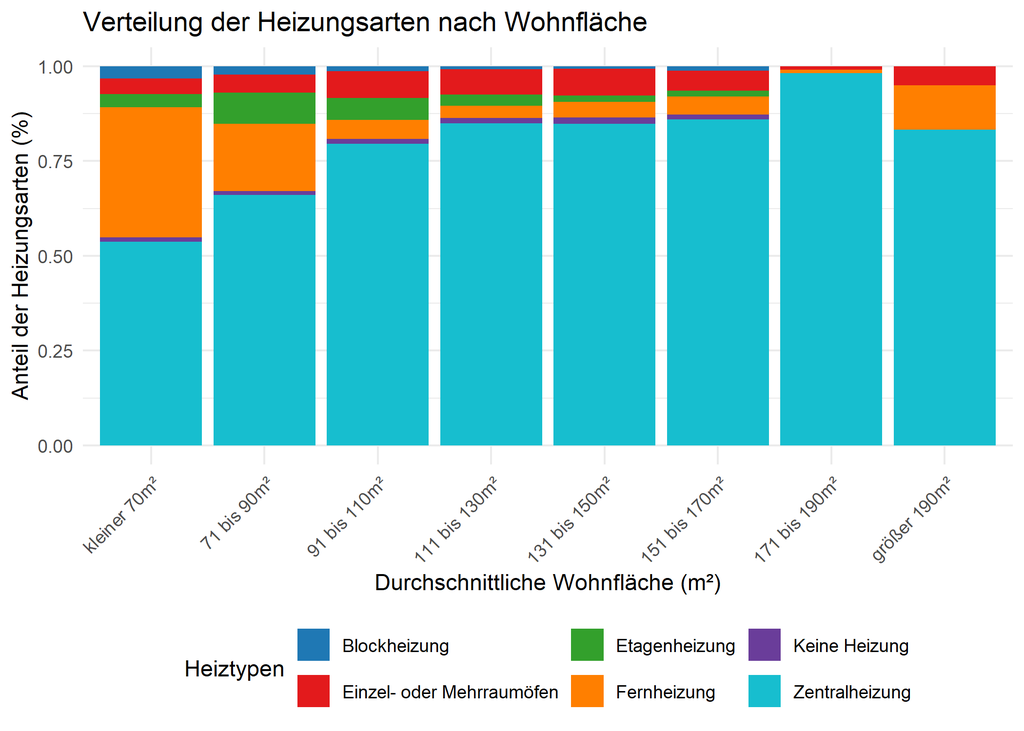

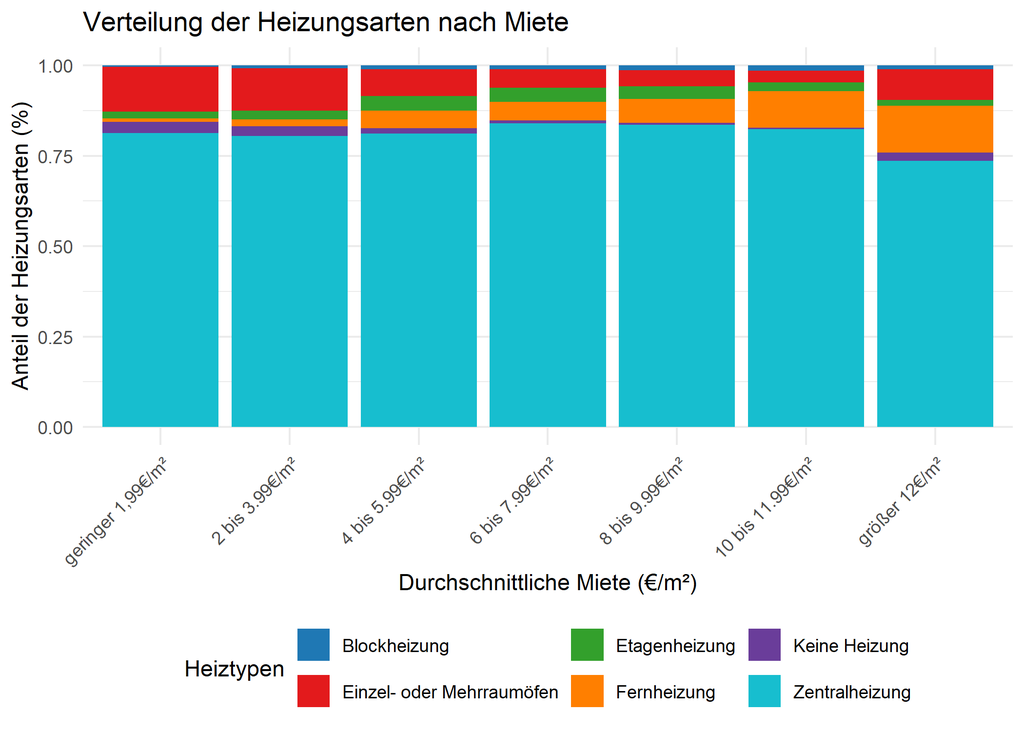

Um die sozialverträgliche Modernisierung des Heizungssektors zu fördern, könnte die Bundesregierung verschiedene Maßnahmen ergreifen. Förderprogramme könnten finanzielle Anreize für Vermieter bieten, moderne Heizsysteme zu installieren, um die Kosten für Mieter zu begrenzen. Eine Deckelung der Umlage von Modernisierungskosten könnte sicherstellen, dass Mieter nicht übermäßig belastet werden. Zudem könnte der soziale Wohnungsbau gestärkt werden, um bezahlbaren Wohnraum mit moderner Heizungstechnik bereitzustellen. Die Förderung erneuerbarer Energien wie Fernwärme könnte langfristig kosteneffiziente und nachhaltige Alternativen schaffen. Schließlich sollten Transparenzpflichten für Vermieter eingeführt werden, um sicherzustellen, dass die Mietpreisgestaltung nachvollziehbar und fair bleibt.

Zusammenfassend zeigt sich, dass die Wahl der Heizungsart eng mit der Wohnungsgröße und den Mietpreisen verknüpft ist. Die Bundesregierung hat zahlreiche Handlungsmöglichkeiten, um die Modernisierung des Heizungssektors sozialverträglich zu gestalten und klimafreundliche Lösungen zu fördern.

Wie Sie in der Aufgabe 15 gesehen haben, haben Ulm und Stuttgart, sowie Dresden und Chemnitz ähnliche Verhältnisse bezüglich der Verteilung der Mietkosten über die Stadt hinweg. Aufgrund dessen beschränken Sie sich bei dieser Aufgabe auf die Städte Stuttgart und Dresden. Hier sollen Sie sich die einzelnen Heizungsarten über die Stadtteile hinweg anschauen, wie sich diese verteilen und ob hier Ähnlichkeiten zur Mietpreissstrukur vorliegt. Weiterhin sind vor allem die Heizungsarten Fernwärme, Zentralheizung und Etagenheizung in viele deutschen Wohnungen größtenteils verbaut, weshalb Sie gerade deswegen diese drei Heiztypen genauer beleuchten und untersuchen sollen.

19. Deshalb sollten Sie sich in einem ersten Schritt [diese Geogitter-Daten für die verschiedenen Heinzungsarten vom statistischen Bundesamt herunterladen](https://www.zensus2022.de/static/Zensus_Veroeffentlichung/Zensus2022_Heizungsart.zip). Speichern Sie die zip-Datei im Ordner `Daten` ab. Nutzen Sie erneut den Datensatz shape_file aus der Aufgabe 4 und joinen Sie die Informationen zu den Heizungsarten über die Variablen `x_mp_1km` und `y_mp_1km`.

In ihrem Datensatz können Sie sehen, dass es Einträge mit “-” gibt. Diese sollen sie für alle Heizungstypen durch 0 ersetzen. Achten Sie auch darauf, dass über alle Heizungstypen hinweg die Werte als numeric vorliegen.

Erstellen Sie nun für die Heizungsarten “Fernheizung”, “Etagenheizung” und “Zentralheizung” eine neue Spalte mit dem Anteil des jeweiligen Heizungstyps an allen Heizungen (`Insgesamt_Heizungsart`) je Gemeinde. Schließlich sollen Sie nun für die drei genannten Heizungsarten eine Karte erzeugen, welche den Anteil je Gitterebene im Stadtbezirk darstellt.

Beschreiben und interpretieren Sie ihre Grafiken. Berücksichtigen Sie dabei insbesondere folgende Fragen:

- Wo liegen Besonderheiten oder Muster in beiden Städten?
- Gibt es in Stuttgart und Dresden Stadtteile, bei denen bestimmte Heizungstypen in Einklang mit den Mietpreisen stehen, genauer gesagt, welche Heizungsarten korrelieren mit höheren oder niedrigeren Mietpreisen? Vergleichen Sie dazu die Ergebnisse aus Aufgabe 15.
- Was könnten Gründe sein, dass in bestimmten Stadtteilen vorwiegend eine bestimmte Form der Heizung eingebaut ist?
- Gibt es Unterschiede zwischen Ost- und Westdeutschland?
- Haben die Städte Stuttgart oder Dresden in den letzen Jahren Modernisierungen angestoßen oder Neuerungen umgesetzt und finanziell unterstützt, sodass es dort zu größeren Anpassungen bei der Heizungstechnik kam?

*Hinweis 1:* Sie sollen insgesamt für jede Stadt (Stuttgart und Dresden) drei verschiedene Karten erzeugen.

*Hinweis 2:* Achten Sie auf eine sinnvolle Einteilung und Darstellung in den Karten. Nutzen Sie die Karten aus vorherigen Aufgaben als Hilfestellung.

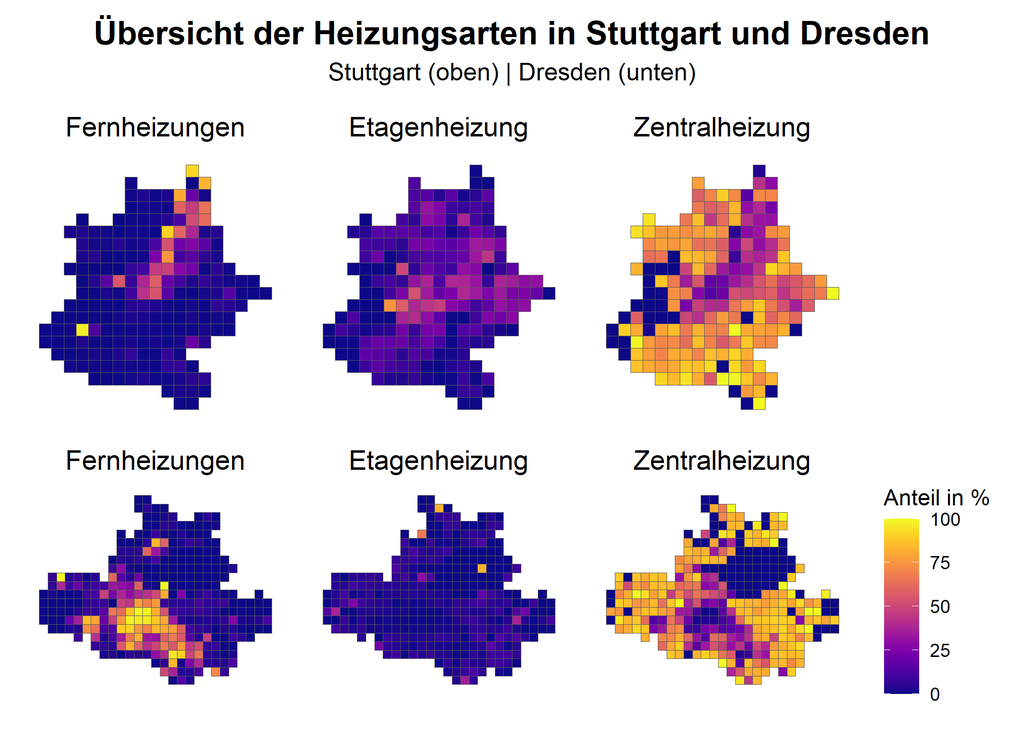

Die Karten zeigen die Anteile der drei betrachteten Heizungsarten (Fern-, Etagen-, und Zentralheizung) in den Städten Stuttgart und Dresden. Auffällig ist, dass Zentralheizungen in beiden Städten klar dominieren, während Etagenheizungen am wenigsten verbreitet sind. Fernheizungen treten lokal begrenzt in Clustern auf.

In Stuttgart ist ein markantes Muster bei den Fernheizungen zu erkennen: Es gibt eine Nordost-Südwest-Linie, bei der die Anteile an Fernheizungen im Nordosten besonders hoch sind und Richtung Stadtzentrum abnehmen. Dies deutet darauf hin, dass Fernheizungen primär in Einzugsgebieten eines Heizkraftwerks genutzt werden. Für Etagenheizungen zeigt Stuttgart ein Cluster in der Innenstadt, wo auch die Mietpreise besonders hoch sind. Zentralheizungen sind in Stuttgart nahezu überall stark vertreten, mit Ausnahmen in den Bereichen, die hohe Fernheizungsanteile aufweisen.

Die regionale Verteilung der Heizungsarten spiegelt historische und strukturelle Unterschiede zwischen Ost- und Westdeutschland wider. Dresden, als ostdeutsche Stadt, hat aufgrund der DDR-Politik, die auf Fernwärme und zentrale Heizkraftwerke setzte, traditionell höhere Anteile an Fernheizungen. In Stuttgart, einer westdeutschen Stadt, ist Fernwärme weniger verbreitet, während moderne Zentralheizungen und alternative Heizsysteme dominieren.

Gründe für die beobachteten Muster liegen in der Infrastruktur und den Baujahren der Gebäude. Fernheizungen sind auf den begrenzten Einzugsbereich von Heizkraftwerken angewiesen und oft ökonomisch günstig. Etagenheizungen sind typisch für ältere Gebäude oder Stadtteile mit hoher Mietnachfrage, während Zentralheizungen in modernen Bauten Standard sind.

Beide Städte haben in den letzten Jahren Modernisierungen angestoßen. In Dresden stand der Ausbau und die Optimierung des Fernwärmenetzes im Fokus, um den CO₂-Ausstoß zu verringern und die Effizienz zu steigern. Die Stadt fördert insbesondere den Anschluss an das Netz in zentralen Stadtteilen.

Stuttgart setzt auf eine umfassende Strategie zur Heizungsmodernisierung: Neben der Förderung der Fernwärme unterstützt die Stadt gezielt Maßnahmen, die zentralisierte Heizsysteme stärken. Beispielsweise bietet sie Zuschüsse für die Umstellung von dezentralen auf zentralisierte Heizungen und für den Ausbau von Infrastruktur, die moderne Heiztechniken ermöglicht. Diese Förderungen sind darauf ausgelegt, sowohl die Energieeffizienz zu steigern als auch die Abhängigkeit von fossilen Energieträgern zu verringern.

Abschließend sollen Sie die Zusatzaufgabe noch einmal rekapitulieren und einige Fragen dazu beantworten.

20. Sie sollen sich noch einmal bewusst werden, was Sie in den vorherigen Aufgaben analysiert haben und in welcher Form ihre Ergebnisse anwendbar und verallgemeinbar sind. Beantworten Sie dazu Frage 1 und 2.

Frage 1: Betrachten Sie hierzu noch einmal exemplarisch die Städte Stuttgart und Dresden.

- Sind die Zusammenhänge zwischen Mietpreisen in den Städten und sozioökonomischer Faktoren vor allem auf Unterschiede zwischen den Städten oder auf Unterschiede innerhalb der Stadt zurückzuführen. Bei welchen Faktoren ist dies der Fall, wo nicht?
- Wie kann der Staat im Hinblick auf die unterschiedlichen Heizungsarten in den Städten eingreifen, um Wohnraum preiswerter zu gestalten?

Frage 2: Schauen Sie sich noch einmal die Verteilung der Heizungsarten (Fern-, Etagen- und Zentralheizungen) für Stuttgart und Dresden in Aufgabe 19 an. Betrachten Sie im Vergleich dazu ihre Grafik aus Aufgabe 8, sowie ihre Tabelle in Aufgabe 13?

- Was fällt Ihnen hier auf?
- Gibt es bestimmte Heizungstypen, die nur in alten oder neuen Wohnungen vorkommen?
- Welche Schlüsse würden Sie ziehen, die mit Handlungen der Politik einhergehen?

Frage 1:

In den Städten Stuttgart und Dresden sind Unterschiede in den Mietpreismodellen stärker durch innerstädtische sozioökonomische Faktoren geprägt als durch Unterschiede zwischen den Städten selbst. Innerhalb Stuttgarts führen die hohe wirtschaftliche Dynamik und die Präsenz gut bezahlter Arbeitsplätze zu einer gesteigerten Nachfrage nach Wohnraum in bestimmten Stadtteilen. Diese bieten nicht nur gute Anbindungen an Arbeitsmärkte, sondern auch hochwertige Bildungs- und Freizeitmöglichkeiten, was die Mietpreise erhöht. In Dresden hingegen sind historische Gegebenheiten nach der Wiedervereinigung von Bedeutung. Viele ehemalige Plattenbaugebäude, die in sozial orientierten Stadtteilen errichtet wurden, sind noch heute stark von den infrastrukturellen Strukturen der DDR geprägt. Diese Bedingungen führen dazu, dass Stadtteile mit höherer Fernheizungsnutzung oft niedrigere Mietpreise aufweisen. In beiden Städten zeigt sich, dass die sozialen und wirtschaftlichen Bedingungen innerhalb der Stadt größere Auswirkungen auf die Mietpreise haben als die Differenzen zwischen Ost- und Westdeutschland.

Um Wohnraum preiswerter zu gestalten, könnte der Staat durch gezielte Fördermaßnahmen eingreifen. Der Ausbau von Fernwärmenetzen in sozialen Brennpunkten bietet eine kostengünstige Heizoption. Investitionen in energetische Gebäudesanierungen könnten die Betriebskosten senken, wenn gleichzeitig Maßnahmen getroffen werden, um Sanierungskosten nicht vollständig auf die Mieten umzulegen. In hochpreisigen Gebieten könnten Förderungen zur Umstellung von ineffizienten Etagenheizungen auf moderne, zentralisierte Systeme Mieten stabilisieren. Steuerliche Anreize für Vermieter und eine faire Verteilung von CO₂-Abgaben könnten langfristig dabei helfen, Wohnkosten zu senken und umweltfreundliche Heizsysteme zu fördern.

Frage 2:

Bei der Verteilung der Heizungsarten in Stuttgart und Dresden fällt auf, dass bestimmte Heizungstypen in älteren bzw. neueren Wohnungen vorkommen. Etagenheizungen sind meist in älteren Gebäuden zu finden, insbesondere in solchen, die vor den 1980er Jahren gebaut wurden. Diese Heizsysteme sind dezentralisiert und weniger energieeffizient. In neueren Wohnungen dominieren hingegen Zentralheizungen, die effizienter und besser an moderne Standards angepasst sind. Fernwärme, die in bestimmten städtischen Gebieten vorhanden ist, wird sowohl in älteren als auch in neueren Wohnungen genutzt, allerdings oft häufiger in jüngeren städtischen Bereichen, die an Fernwärmenetze angeschlossen sind.

Politisch könnte man sich darauf konzentrieren, den Ausbau der Fernwärme in neuen Wohnprojekten in Dresden zu fördern und gleichzeitig in Stuttgart umfassende Sanierungsmaßnahmen für ältere Gebäude mit ineffizienten Heizlösungen anzubieten. Beide Städte könnten durch gezielte Investitionen in die Optimierung bestehender Heizsysteme von einer gesteigerten Gesamtenergieeffizienz profitieren. Diese Strategie würde nicht nur die Wohnkosten stabilisieren, sondern auch die Abhängigkeit von fossilen Energieträgern verringern und gleichzeitig die Umweltbelastung senken.